# Project Part F: All Together Now

[figure not shown]

```r
#analyst = "Firstname Lastname" # Replace this with your name
analyst = "Oscar Li"
```

```r
f = "setup.R"; for (i in 1:10) { if (file.exists(f)) break else f = paste0("../", f) }; source(f)
options(repr.matrix.max.rows=674)
update_geom_defaults("point", list(size=1))
update_geom_defaults("col", list(fill=PALETTE[1]))
```

## Introduction

### Decision

Recommend a portfolio of 12 company investments that maximizes 12-month profit on a \$1,000,000 investment.

### Approach

Retrieve a public company fundamentals dataset comprising thousands of US companies from quarters 1, 2, 3, and 4 of year 2017 + company stock price data for those companies from quarter 4 of year 2018.

Prepare the data so that each company and its associated information is represented as a single observation.

Apply various descriptive statistics and data visualizations to look for interesting patterns and inter-company relationships.

Transform the dataset using variable filtration, imputation, principal component analysis, and other methods to ready it for predictive model construction.

Build models to predict whether stock price will grow more than 30% over 12 months, given 12 months of past company fundamentals data, using machine learning model construction methods. Evaluate and tune the models for optimal business performance.

Build models to predict how much stock price will grow over 12 months, given 12 months of past company fundamentals data, using machine learning model construction methods. Evaluate and tune the model for optimal business performance.

Identify the best performing model.

Retrieve an investment opportunities dataset, comprising fundamentals for some set of public companies over some one-year period. Transform the representation of the investment opportunities to match the representation expected by the best performing model, leveraging previous analysis.

Use the best performing model to make predictions about the investment opportunities and accordingly recommend a portfolio of 12 company investments.

### Data Source

Data files:

- Data Dictionary.csv
- Company Fundamentals 2017.csv
- Company Fundamentals 2018.csv

The datasets and accompanying data dictionary are sourced from ...

- Wharton Research Data Services > Compustat - Capital IQ from Standard & Poor's > North America - Daily > Fundamentals Quarterly (https://wrds-www.wharton.upenn.edu/)
  - Date Variable: Data Date
  - Date Range: 2017-01 to 2017-12 -or- 2018-01 to 2018-12
  - Company Codes: Search the entire database
    - Consolidtaion Level: C, Output
    - Industry Format: INDL, FS, Output
    - Data Format: STD, Output
    - Population Source: D, Output
    - Quarter Type: Fiscal View, Output
    - Currency: USD, Output (not CAD)
    - Company Status: Active, Output (not Inactive)
  - Variable Types: Data Items, Select All (674)
  - Query output:
    - Output format: comma-delimited text
    - Compression type: None
    - Data format: MMDDYY10

The data dictionary is from Variable Descriptions tab, copied to Excel, saved in csv format.

**For this project, do not source any additional data from year 2019.**

## Business Model & Business Parameters

The business model is ...

$\begin{align} & \textsf{profit} = \left( \sum_{i \in \textsf{portfolio}} (1 + \textsf{growth}_i) \times \textsf{allocation}_i \right) - \textsf{budget} \\ \\ & \textsf{profit rate} = \textsf{profit} \div \textsf{budget} \\ \\ & \textsf{budget} = \sum_{i \in \textsf{portfolio}} \textsf{allocation}_i \\ \\ \end{align}$

Business parameters include ...

- $\textsf{budget}$ is total investment to allocate across the companies in the portfolio
- $\textsf{portfolio size}$ is number of companies in the portfolio
- $\textsf{allocation}$ is vector of amounts to allocate to specific companies in the portfolio, must sum to budget
- $\textsf{threshold}$ is growth that qualifies as lowest attractive growth

```r
# Set the business parameters.

budget = 1000000
portfolio_size = 12
allocation = rep(1000000/12, 12) # you can keep or change this setting
threshold = 0.30 # you can keep or change this setting

# x = 1000000 / (12+11+10+9+8+7+6+5+4+3+2+1)
# allocation = c(12*x, 11*x, 10*x, 9*x, 8*x, 7*x, 6*x, 5*x, 4*x, 3*x, 2*x, 1*x) # another of several possible allocations

layout(fmt(budget), fmt(portfolio_size),fmt(allocation), fmt(threshold))
```

| budget |
| --- |
| 1000000 |

| portfolio_size |
| --- |
| 12 |

| allocation |
| --- |
| 83333.33 |
| 83333.33 |
| 83333.33 |
| 83333.33 |
| 83333.33 |
| 83333.33 |
| 83333.33 |
| 83333.33 |
| 83333.33 |
| 83333.33 |
| 83333.33 |
| 83333.33 |

| threshold |
| --- |
| 0.3 |

Portfolio to be filled with companies that will maximize profit.

## Data

### Retrieve Raw Data

```r
# Retrieve the 2017 data.
# How many observations and variables?

data2017 = read.csv("Company Fundamentals 2017.csv", header=TRUE, na.strings=c("NA", ""), stringsAsFactors=FALSE)

fmt(size(data2017), NA)
fmt(data2017[1:3,], FFO, "left")
```

| observations | variables |
| --- | --- |
| 33269 | 680 |

**data2017 (first few observations)**

| gvkey | datadate | fyearq | fqtr | fyr | indfmt | consol | popsrc | datafmt | tic | cusip | conm | acctchgq | acctstdq | adrrq | ajexq | ajpq | bsprq | compstq | curcdq | curncdq | currtrq | curuscnq | datacqtr | datafqtr | finalq | ogmq | rp | scfq | srcq | … |
| --- | --- | --- | --- | --- | --- | --- | --- | --- | --- | --- | --- | --- | --- | --- | --- | --- | --- | --- | --- | --- | --- | --- | --- | --- | --- | --- | --- | --- | --- | --- |
| 1004 | 02/28/2017 | 2016 | 3 | 5 | INDL | C | D | STD | AIR | 000361105 | AAR CORP | NA | DS | NA | 1 | 1 | NA | AZ | USD | USD | 1 | NA | 2017Q1 | 2016Q3 | Y | NA | Q | 7 | 5 | … |
| 1004 | 05/31/2017 | 2016 | 4 | 5 | INDL | C | D | STD | AIR | 000361105 | AAR CORP | NA | DS | NA | 1 | 1 | NA | AZ | USD | USD | 1 | NA | 2017Q2 | 2016Q4 | Y | NA | Q | 7 | 5 | … |
| 1004 | 08/31/2017 | 2017 | 1 | 5 | INDL | C | D | STD | AIR | 000361105 | AAR CORP | NA | DS | NA | 1 | 1 | NA | AZ | USD | USD | 1 | NA | 2017Q3 | 2017Q1 | Y | NA | Q | 7 | 5 | … |

```r
# Retrieve the 2018 data.
# How many observations and variables?

data2018 = read.csv("Company Fundamentals 2018.csv", header=TRUE, na.strings=c("NA", ""), stringsAsFactors=FALSE)
fmt(size(data2018), NA)
fmt(data2018[1:3,], FFO, "left")
```

| observations | variables |
| --- | --- |
| 35728 | 680 |

**data2018 (first few observations)**

| gvkey | datadate | fyearq | fqtr | fyr | indfmt | consol | popsrc | datafmt | tic | cusip | conm | acctchgq | acctstdq | adrrq | ajexq | ajpq | bsprq | compstq | curcdq | curncdq | currtrq | curuscnq | datacqtr | datafqtr | finalq | ogmq | rp | scfq | srcq | … |
| --- | --- | --- | --- | --- | --- | --- | --- | --- | --- | --- | --- | --- | --- | --- | --- | --- | --- | --- | --- | --- | --- | --- | --- | --- | --- | --- | --- | --- | --- | --- |
| 1004 | 02/28/2018 | 2017 | 3 | 5 | INDL | C | D | STD | AIR | 000361105 | AAR CORP | NA | DS | NA | 1 | 1 | NA | NA | USD | USD | 1 | NA | 2018Q1 | 2017Q3 | Y | NA | Q | 7 | 5 | … |
| 1004 | 05/31/2018 | 2017 | 4 | 5 | INDL | C | D | STD | AIR | 000361105 | AAR CORP | NA | DS | NA | 1 | 1 | NA | NA | USD | USD | 1 | NA | 2018Q2 | 2017Q4 | Y | NA | Q | 7 | 5 | … |
| 1004 | 08/31/2018 | 2018 | 1 | 5 | INDL | C | D | STD | AIR | 000361105 | AAR CORP | ASU14-09 | DS | NA | 1 | 1 | NA | NA | USD | USD | 1 | NA | 2018Q3 | 2018Q1 | Y | NA | Q | 7 | 5 | … |

### Prepare

*2017 Data:*

Partition the dataset by calendar quarter in which information is reported by first adding a synthetic variable to indicate such. Then partition into four new datasets, one for each quarter, and drop the quarter variables. Additionally, filter the observations to include only those with non-missing `prccq` $\geq$ 3. Then remove any observations about companies that reported more than once per quarter. Then change all the variable names (except for the `gvkey`, `tic`, and `conm` variables) by suffixing them with quarter information - e.g., in the Quarter 1 dataset, `prccq` becomes `prccq.q1`, etc.

Consolidate the four quarter datasets into one dataset, with one observation per company that includes variables for all four quarters. Remove any observations with missing `prccq.q4` values.

*2018 Data:*

Filter the dataset by calendar quarter in which information is reported by first adding a synthetic variable to indicate such, and then select only observations with information reported in quarter 4. Additionally, filter the observations to include only those with non-missing `prccq`, and keep only the `gvkey` and `prccq` variables. Then remove any observations about companies that reported more than once per quarter.

*Consolidate:*

Consolidate the processed 2017 dataset and processed 2018 dataset, keeping only observations that have both 2017 and 2018 information. Then add these 2 synthetic variables:

$\begin{align} \textsf{growth} & = \left( \textsf{prccq} - \textsf{prccq.q4} \right) \div \textsf{prccq.q4} \\ \textsf{big growth} & = \textsf{growth} \geq \textsf{threshold} \end{align}$

```r
# Partition the 2017 data.

# How many observations and variables in each quarter dataset?

data2017$quarter = quarter(mdy(data2017[,2]))

data.current.q1 = data2017[(data2017$quarter==1) & !is.na(data2017$prccq) & (data2017$prccq>=3), -ncol(data2017)]
data.current.q2 = data2017[(data2017$quarter==2) & !is.na(data2017$prccq) & (data2017$prccq>=3), -ncol(data2017)]
data.current.q3 = data2017[(data2017$quarter==3) & !is.na(data2017$prccq) & (data2017$prccq>=3), -ncol(data2017)]
data.current.q4 = data2017[(data2017$quarter==4) & !is.na(data2017$prccq) & (data2017$prccq>=3), -ncol(data2017)]

data.current.q1 = data.current.q1[!duplicated(data.current.q1$gvkey),]
data.current.q2 = data.current.q2[!duplicated(data.current.q2$gvkey),]
data.current.q3 = data.current.q3[!duplicated(data.current.q3$gvkey),]
data.current.q4 = data.current.q4[!duplicated(data.current.q4$gvkey),]

colnames(data.current.q1)[-c(1, 10, 12)] = paste0(colnames(data.current.q1)[-c(1, 10, 12)], ".q1")
colnames(data.current.q2)[-c(1, 10, 12)] = paste0(colnames(data.current.q2)[-c(1, 10, 12)], ".q2")
colnames(data.current.q3)[-c(1, 10, 12)] = paste0(colnames(data.current.q3)[-c(1, 10, 12)], ".q3")
colnames(data.current.q4)[-c(1, 10, 12)] = paste0(colnames(data.current.q4)[-c(1, 10, 12)], ".q4")


layout(fmt(size(data.current.q1)),
       fmt(size(data.current.q2)),
       fmt(size(data.current.q3)),
       fmt(size(data.current.q4)))
```

**size(data.current.q1)**

| observations | variables |
| --- | --- |
| 4324 | 680 |

**size(data.current.q2)**

| observations | variables |
| --- | --- |
| 4387 | 680 |

**size(data.current.q3)**

| observations | variables |
| --- | --- |
| 4397 | 680 |

**size(data.current.q4)**

| observations | variables |
| --- | --- |
| 4434 | 680 |

```r
# Consolidate the 2017 data partitions.
# How many observations and variables?

m12 = merge(data.current.q1, data.current.q2, by=c("gvkey", "tic", "conm"), all=TRUE)
m34 = merge(data.current.q3, data.current.q4, by=c("gvkey", "tic", "conm"), all=TRUE)
data.current = merge(m12, m34, by=c("gvkey", "tic", "conm"), all=TRUE, sort=TRUE)

data.current = data.current[!is.na(data.current$prccq.q4),]

size(data.current)
fmt(data.current[1:3, 1:13], "data.current (first few observations, first few variables variables)", "left")
```

A data.frame: 1 × 2

| observations <int> | variables <int> |
| --- | --- |
| 4434 | 2711 |

**data.current (first few observations, first few variables variables)**

| gvkey | tic | conm | datadate.q1 | fyearq.q1 | fqtr.q1 | fyr.q1 | indfmt.q1 | consol.q1 | popsrc.q1 | datafmt.q1 | cusip.q1 | acctchgq.q1 |
| --- | --- | --- | --- | --- | --- | --- | --- | --- | --- | --- | --- | --- |
| 1004 | AIR | AAR CORP | 02/28/2017 | 2016 | 3 | 5 | INDL | C | D | STD | 000361105 | NA |
| 1045 | AAL | AMERICAN AIRLINES GROUP INC | 03/31/2017 | 2017 | 1 | 12 | INDL | C | D | STD | 02376R102 | NA |
| 1050 | CECE | CECO ENVIRONMENTAL CORP | 03/31/2017 | 2017 | 1 | 12 | INDL | C | D | STD | 125141101 | NA |

```r
# Filter the 2018 data.

data2018$quarter = quarter(mdy(data2018[,2]))
data.future.q4 = data2018[(data2018$quarter==4) & !is.na(data2018$prccq), c("gvkey", "prccq")]
data.future.q4 = data.future.q4[!duplicated(data.future.q4$gvkey),]

size(data.future.q4)
fmt(data.future.q4[1:6,], FFO)
```

A data.frame: 1 × 2

| observations <int> | variables <int> |
| --- | --- |
| 5968 | 2 |

**data.future.q4 (first few observations)**

| gvkey | prccq |
| --- | --- |
| 1004 | 43.69 |
| 1045 | 32.11 |
| 1050 | 6.75 |
| 1062 | 8.66 |
| 1072 | 15.25 |
| 1075 | 85.20 |

```r
# Consolidate the 2017 data and 2018 data.

data = merge(data.current, data.future.q4, by="gvkey", all=FALSE)

data$growth = (data$prccq - data$prccq.q4) / data$prccq.q4
data$big_growth = factor(data$growth >= threshold, levels=c(TRUE, FALSE), labels=c("YES", "NO"))

data = front(data, c("big_growth", "growth", "prccq"))


size(data)
fmt(data[1:3, 1:13], "data (first few observations, first few variables variables)", "left")
```

A data.frame: 1 × 2

| observations <int> | variables <int> |
| --- | --- |
| 4305 | 2714 |

**data (first few observations, first few variables variables)**

| big_growth | growth | prccq | gvkey | tic | conm | datadate.q1 | fyearq.q1 | fqtr.q1 | fyr.q1 | indfmt.q1 | consol.q1 | popsrc.q1 |
| --- | --- | --- | --- | --- | --- | --- | --- | --- | --- | --- | --- | --- |
| NO | 0.0507456 | 43.69 | 1004 | AIR | AAR CORP | 02/28/2017 | 2016 | 3 | 5 | INDL | C | D |
| NO | -0.3828560 | 32.11 | 1045 | AAL | AMERICAN AIRLINES GROUP INC | 03/31/2017 | 2017 | 1 | 12 | INDL | C | D |
| YES | 0.3157895 | 6.75 | 1050 | CECE | CECO ENVIRONMENTAL CORP | 03/31/2017 | 2017 | 1 | 12 | INDL | C | D |

## Exploratory Data Analysis

```r
# Show fraction of observations that are missing price data.

fraction <- round(sum(is.na(data$prccq.q1) |
                      is.na(data$prccq.q2) |
                      is.na(data$prccq.q3) |
                      is.na(data$prccq.q4)) / nrow(data),7)

fmt(fraction, "fraction of observations with missing price data")
```

| fraction of observations with missing price data |
| --- |
| 0.0857143 |

```r
# Show another interesting descriptive statistic.


# I present the Quantile of columns growth, Quarter Close Price, and IQR for Growth and Quarter Close Price.
# IQR (Third - First Quantile) for column Growth and Quarterly Close Price


layout(fmt(t(quantile(data$growth)), "Growth Quantile"),
       fmt(t(quantile(data$prccq)), "Quarterly Close Price Quantile"))

layout(fmt(IQR(data$growth), "IQR of Growth"),
       fmt(IQR(data$prccq), "IQR of Quarterly Close Price Quantile"))
```

**Growth Quantile**

| 0% | 25% | 50% | 75% | 100% |
| --- | --- | --- | --- | --- |
| -0.9956 | -0.3354388 | -0.1492019 | 0.01973 | 10.24283 |

**Quarterly Close Price Quantile**

| 0% | 25% | 50% | 75% | 100% |
| --- | --- | --- | --- | --- |
| 0.025 | 9.4 | 20.98 | 45.49 | 14450 |

| IQR of Growth |
| --- |
| 0.3551688 |

| IQR of Quarterly Close Price Quantile |
| --- |
| 36.09 |

```r
# Show another interesting descriptive statistic.

# correlation between prccq.q4 and prccq?
# correlation between prccq.q4 and growth?

correlations = data.frame(prccq.q4_prccq = cor(data$prccq.q4, data$prccq),
                          prccq.q4_growth = cor(data$prccq.q4, data$growth))

fmt(correlations, "correlations")
```

**correlations**

| prccq.q4_prccq | prccq.q4_growth |
| --- | --- |
| 0.9602728 | 0.0088286 |

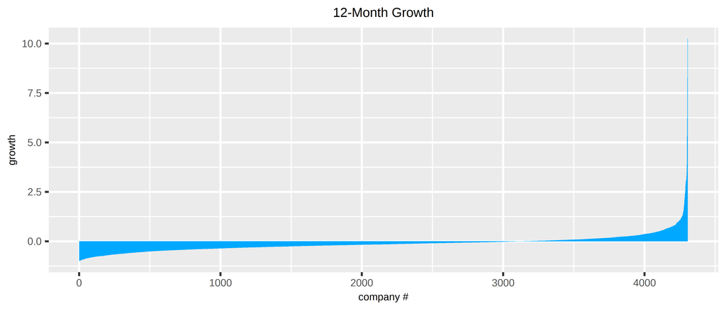

```r
# Visualize growth across companies.

ggplot(data) + ggtitle("12-Month Growth") + xlab("company #") + ylab("growth") +
geom_col(aes(x=1:nrow(data), y = sort(data$growth)))
```

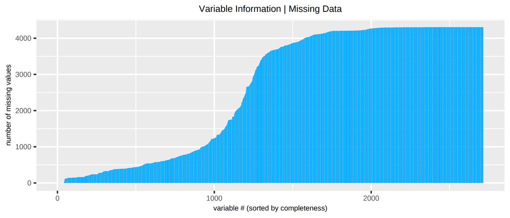

```r
# Visualize the amount of missing data across variables.

ggplot() + ggtitle("Variable Information | Missing Data") +
xlab("variable # (sorted by completeness)") +
ylab("number of missing values") +
geom_col(aes(x = 1:ncol(data), y = sort(var_info.na_count(data))), width = 0.1)
```

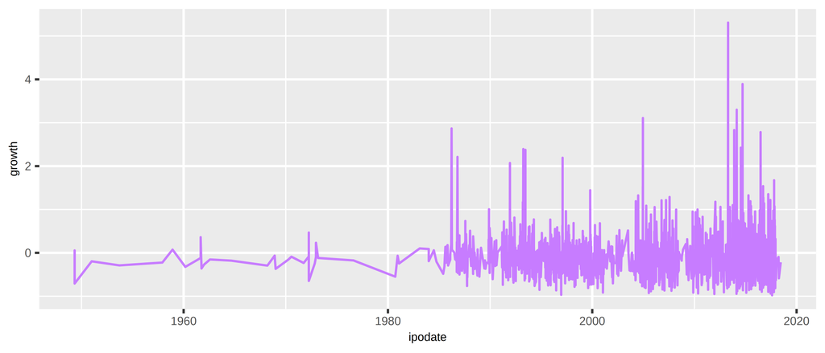

```r
# Show another interesting visualization.

ipo_growth <- na.omit(data.frame(growth = data$growth, ipodate = data$ipodate.q4))
ipo_growth$ipodate <- as.Date(ipo_growth$ipodate, "%m/%d/%Y") # change character to Date objects
ipo_growth <- ipo_growth[order(ipo_growth$ipodate),] # order by date
rownames(ipo_growth) <- 1:nrow(ipo_growth) # reindex

ggplot(ipo_growth) + geom_line(aes(x = ipodate, y = growth), color = PALETTE[4])
```

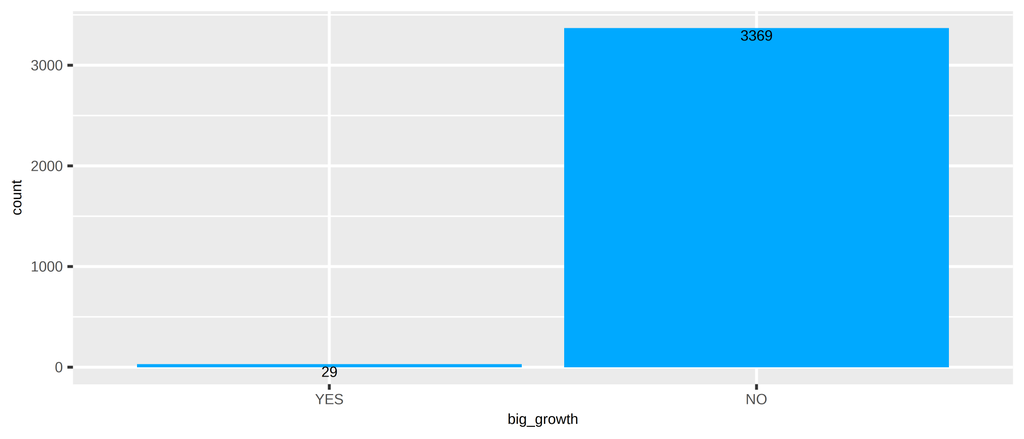

```r
# Show another interesting visualization.

book_2_cap <- na.omit(data.frame(company_index = data$tic,
                                 big_growth = data$big_growth,
                                 share_outstand = data$cshoq.q4,
                                 share_price = data$prccq.q4,
                                 market_value = data$cshoq.q4 * data$prccq.q4,
                                 common_ordinary_equity = data$ceqq.q4
                                ))

book_2_cap$book_to_market_ratio <- (book_2_cap$common_ordinary_equity / book_2_cap$market_value)
book_2_cap$assess <- factor(book_2_cap$book_to_market_ratio >= 1,
                            levels = c(TRUE, FALSE),
                            labels = c("Undervalue", "Overvalue"))

undervalue_filter <- book_2_cap[(book_2_cap$big_growth == "YES" & book_2_cap$assess == "Undervalue"),]
overvalue_filter <- book_2_cap[(book_2_cap$big_growth == "NO" & book_2_cap$assess == "Overvalue"),]

assessment <- rbind(undervalue_filter, overvalue_filter)
assessment <- assessment[order(assessment$book_to_market_ratio, decreasing = TRUE), ]
ggplot(assessment, aes(x = big_growth)) + geom_bar() + geom_text(aes(label = ..count..),
                                                                 stat = "count",
                                                                 vjust = 1.25, color = "black")
```

I used the Book to Market ratio to find out there are more companies assessed overvalue while we label NO to big_growth. The ratio finds the market value of the company relative to its actual worth. Any rations greater than or equal to 1 is consider undervalue. This bar chart could be use to change investment decisions, where we can do research into the 29 companies that has big growth and undervalue, and invest more in them. We could do the vice versa. For example, DTLA.P is very overvalue, their stock price was at 28.8 in 2017, currently they are priced 11.26.

Book to Market ratio is not the only metric to measure company growth, additionally, tech companies do not have many physical asseset, which they tend to have lower book-to-market ratio.

## Data Transformation

Transform data representation:

- Filter the data to include only predictor variables with at least 95% non-missing values.
- Impute missing data ...
  - for each numerical variable, use the mean of non-missing values
  - for each non-numerical variable, use the mode of non-missing values
- Filter the data to include only numerical (numeric and integer types) variables with non-zero variance.
- Transform numerical predictor variables to principal component representation.
- Restore the outcome and identifier variables.
- Filter in outcome and identifier variables, and first three principal components.

```r
# Specify outcome, identifier, and predictor variables.

outvars = c("big_growth", "growth", "prccq")
idvars  = c("gvkey", "tic", "conm")
prevars = setdiff(colnames(data), outvars)
layout(fmt(outvars), fmt(idvars), fmt(prevars[1:10], FFO))
```

| outvars |
| --- |
| big_growth |
| growth |
| prccq |

| idvars |
| --- |
| gvkey |
| tic |
| conm |

| prevars (first few observations) |
| --- |
| gvkey |
| tic |
| conm |
| datadate.q1 |
| fyearq.q1 |
| fqtr.q1 |
| fyr.q1 |
| indfmt.q1 |
| consol.q1 |
| popsrc.q1 |

```r
# Filter out sparse variables.

data.filter <- data[,prevars][,var_info.na_count(data[,prevars]) <
                               (0.05 * nrow(data[ ,prevars]))]
fmt(size(data.filter), "data after variable filtration")
```

**data after variable filtration**

| observations | variables |
| --- | --- |
| 4305 | 200 |

```r
# Impute missing data.

data.imputed <- impute(data.filter)
data.impute.stored <- get_impute(data.filter)
fmt(size(data.imputed), "data after imputation")
```

**data after imputation**

| observations | variables |
| --- | --- |
| 4305 | 200 |

```r
# Transform numerical predictor variables to principal component representation
data.numerical <- data.imputed[, var_info.type(data.imputed)
                               %in% c("numeric", "integer")]
variance <- var_info.var(data.numerical)
data.remove_0 <- data.numerical[, variance > 0]
pc <- prcomp(data.remove_0, scale = TRUE, retx = TRUE)
data.pc <- as.data.frame(pc$x)
fmt(size(data.pc), NA)
fmt(data.pc[1:5,], FFO, "left")
```

| observations | variables |
| --- | --- |
| 4305 | 151 |

**data.pc (first few observations)**

| PC1 | PC2 | PC3 | PC4 | PC5 | PC6 | PC7 | PC8 | PC9 | PC10 | PC11 | PC12 | PC13 | PC14 | PC15 | PC16 | PC17 | PC18 | PC19 | PC20 | PC21 | PC22 | PC23 | PC24 | PC25 | PC26 | PC27 | PC28 | PC29 | PC30 | … |
| --- | --- | --- | --- | --- | --- | --- | --- | --- | --- | --- | --- | --- | --- | --- | --- | --- | --- | --- | --- | --- | --- | --- | --- | --- | --- | --- | --- | --- | --- | --- |
| 1.409764 | 0.2124544 | -0.1873581 | -1.3446137 | -0.0365207 | -5.0250338 | 0.8071181 | 0.2308762 | 0.4172118 | -1.4908250 | 0.3994419 | 0.5379293 | -0.5058319 | -0.2376358 | -0.8975268 | 0.4677236 | -0.3083398 | -0.5156390 | -0.1502376 | 0.2972639 | -0.4994577 | -0.0989560 | 1.9734201 | -0.6419359 | -0.1415775 | 0.2177932 | -0.6018009 | 0.6090365 | -0.5942307 | 0.5064154 | … |
| -2.809314 | 0.2246363 | 1.4366121 | -3.2326072 | 0.3686460 | 1.4262023 | 2.0046301 | -1.6756734 | 1.5733711 | -0.3330458 | -1.3085775 | 0.5722713 | -0.8129528 | -1.0506235 | -0.0733606 | -0.3887728 | -0.5811171 | -0.2253818 | -0.0110649 | 1.1777649 | -0.8164647 | 0.0744744 | 0.5922569 | 0.0166959 | 0.9119773 | 1.1849860 | -1.4300747 | 0.4663901 | -0.0315042 | 0.8458528 | … |
| 1.524722 | 0.4396434 | -0.1678561 | -0.4733925 | 0.6652930 | 0.3661023 | 2.2428475 | 1.3492993 | 0.0612739 | 0.0644994 | -0.0752577 | 0.1219964 | -0.4036427 | -0.2399168 | 0.4368454 | -0.2696851 | -0.0614978 | -0.1147493 | -0.1751381 | 0.4814173 | -0.7812042 | -0.2489656 | 0.4834659 | -0.1214996 | -0.1350113 | 0.0009309 | -1.1692650 | 0.7544172 | -0.7797540 | 0.6789409 | … |
| 1.573669 | 0.6384403 | 0.0122754 | 1.2308994 | 0.0509725 | 0.6109604 | -0.7640124 | -0.7708479 | 0.1304121 | -1.1817421 | 0.3874768 | 0.3707853 | 0.2987798 | -0.6561800 | -0.8139691 | 0.2307742 | -0.3185639 | -0.1534360 | 0.2754846 | 0.1865421 | -0.1837970 | -0.0273412 | 0.4362197 | -0.2083792 | 0.0854137 | 0.1450627 | -0.2331361 | 0.2449853 | -0.1034983 | 0.0839695 | … |
| 1.281265 | 0.4529129 | 0.0929383 | -0.8541629 | -0.3221003 | -4.7346676 | -1.0982939 | -0.7556450 | -0.1832943 | -1.5742726 | 0.3493623 | -0.3256910 | 1.6853485 | -0.2919847 | 0.5216330 | -0.1301963 | 0.1159968 | 0.4036542 | -0.3380043 | -0.7317709 | 0.1859148 | -0.0260968 | 2.1003249 | -1.3011840 | -0.2738841 | 0.5311304 | -0.0969595 | 0.3444688 | 0.0120473 | -0.7692723 | … |

```r
# Restore the outcome and indentifier variables to the data.

data.pcv <- cbind(data[,outvars], data[,idvars], data.pc)
fmt(size(data.pcv), NA)
fmt(data.pcv[1:5,], FFO, "left")
```

| observations | variables |
| --- | --- |
| 4305 | 157 |

**data.pcv (first few observations)**

| big_growth | growth | prccq | gvkey | tic | conm | PC1 | PC2 | PC3 | PC4 | PC5 | PC6 | PC7 | PC8 | PC9 | PC10 | PC11 | PC12 | PC13 | PC14 | PC15 | PC16 | PC17 | PC18 | PC19 | PC20 | PC21 | PC22 | PC23 | PC24 | … |
| --- | --- | --- | --- | --- | --- | --- | --- | --- | --- | --- | --- | --- | --- | --- | --- | --- | --- | --- | --- | --- | --- | --- | --- | --- | --- | --- | --- | --- | --- | --- |
| NO | 0.0507456 | 43.69 | 1004 | AIR | AAR CORP | 1.409764 | 0.2124544 | -0.1873581 | -1.3446137 | -0.0365207 | -5.0250338 | 0.8071181 | 0.2308762 | 0.4172118 | -1.4908250 | 0.3994419 | 0.5379293 | -0.5058319 | -0.2376358 | -0.8975268 | 0.4677236 | -0.3083398 | -0.5156390 | -0.1502376 | 0.2972639 | -0.4994577 | -0.0989560 | 1.9734201 | -0.6419359 | … |
| NO | -0.3828560 | 32.11 | 1045 | AAL | AMERICAN AIRLINES GROUP INC | -2.809314 | 0.2246363 | 1.4366121 | -3.2326072 | 0.3686460 | 1.4262023 | 2.0046301 | -1.6756734 | 1.5733711 | -0.3330458 | -1.3085775 | 0.5722713 | -0.8129528 | -1.0506235 | -0.0733606 | -0.3887728 | -0.5811171 | -0.2253818 | -0.0110649 | 1.1777649 | -0.8164647 | 0.0744744 | 0.5922569 | 0.0166959 | … |
| YES | 0.3157895 | 6.75 | 1050 | CECE | CECO ENVIRONMENTAL CORP | 1.524722 | 0.4396434 | -0.1678561 | -0.4733925 | 0.6652930 | 0.3661023 | 2.2428475 | 1.3492993 | 0.0612739 | 0.0644994 | -0.0752577 | 0.1219964 | -0.4036427 | -0.2399168 | 0.4368454 | -0.2696851 | -0.0614978 | -0.1147493 | -0.1751381 | 0.4814173 | -0.7812042 | -0.2489656 | 0.4834659 | -0.1214996 | … |
| NO | -0.2164740 | 8.66 | 1062 | ASA | ASA GOLD AND PRECIOUS METALS | 1.573669 | 0.6384403 | 0.0122754 | 1.2308994 | 0.0509725 | 0.6109604 | -0.7640124 | -0.7708479 | 0.1304121 | -1.1817421 | 0.3874768 | 0.3707853 | 0.2987798 | -0.6561800 | -0.8139691 | 0.2307742 | -0.3185639 | -0.1534360 | 0.2754846 | 0.1865421 | -0.1837970 | -0.0273412 | 0.4362197 | -0.2083792 | … |
| NO | -0.1184971 | 15.25 | 1072 | AVX | AVX CORP | 1.281265 | 0.4529129 | 0.0929383 | -0.8541629 | -0.3221003 | -4.7346676 | -1.0982939 | -0.7556450 | -0.1832943 | -1.5742726 | 0.3493623 | -0.3256910 | 1.6853485 | -0.2919847 | 0.5216330 | -0.1301963 | 0.1159968 | 0.4036542 | -0.3380043 | -0.7317709 | 0.1859148 | -0.0260968 | 2.1003249 | -1.3011840 | … |

```r
# Filter in outcome and identifier variables, and first three principal components.
# How many observations and variables?
# Show first few observations of transformed data.

data.pcv.filter <- data.pcv[,c(outvars, idvars, "PC1", "PC2", "PC3")]
prevars.adj <- c(idvars, "PC1", "PC2", "PC3")
layout(fmt(outvars), fmt(prevars.adj, "prevars"))
fmt(size(data.pcv.filter), NA)
fmt(data.pcv.filter[1:6,], "data (first few observation)", "left")
```

| outvars |
| --- |
| big_growth |
| growth |
| prccq |

| prevars |
| --- |
| gvkey |
| tic |
| conm |
| PC1 |
| PC2 |
| PC3 |

| observations | variables |
| --- | --- |
| 4305 | 9 |

**data (first few observation)**

| big_growth | growth | prccq | gvkey | tic | conm | PC1 | PC2 | PC3 |
| --- | --- | --- | --- | --- | --- | --- | --- | --- |
| NO | 0.0507456 | 43.69 | 1004 | AIR | AAR CORP | 1.4097638 | 0.2124544 | -0.1873581 |
| NO | -0.3828560 | 32.11 | 1045 | AAL | AMERICAN AIRLINES GROUP INC | -2.8093139 | 0.2246363 | 1.4366121 |
| YES | 0.3157895 | 6.75 | 1050 | CECE | CECO ENVIRONMENTAL CORP | 1.5247216 | 0.4396434 | -0.1678561 |
| NO | -0.2164740 | 8.66 | 1062 | ASA | ASA GOLD AND PRECIOUS METALS | 1.5736687 | 0.6384403 | 0.0122754 |
| NO | -0.1184971 | 15.25 | 1072 | AVX | AVX CORP | 1.2812646 | 0.4529129 | 0.0929383 |
| NO | 0.0002348 | 85.20 | 1075 | PNW | PINNACLE WEST CAPITAL CORP | 0.3697622 | -0.4860613 | -0.0128364 |

### Store Transformed Data & Transformation Meta-Data

```r
saveRDS(data.filter, "My Filter Proj F.rds")
```

```r
saveRDS(data.impute.stored, "My Imputation Proj F.rds")
```

```r
saveRDS(pc, "My PC F.rds")
```

```r
saveRDS(prevars.adj, "My Predictors Proj F.rds")
```

```r
write.csv(data.pcv.filter, "My Data Proj F.csv", row.names=FALSE)
```

## Model 1

Model 1 is a naive Bayes classifier that predicts whether or not a company stock price will grow by 30% or more at 12 months.

```r
# Build, evaluate, and tune a naive Bayes model by iterating through PC1, PC2, PC3 predictor variable combinations.
# Show the allocations assumed, predictor variable combination and estimated profit for the searched and best performing models.

tune <- data.frame()
start_time <- Sys.time()
for(f in exhaustive(c("PC1", "PC2", "PC3", "big_growth"), keep = "big_growth")) # try differnt predictor variables
for(q in c(0.15, 0.25, 0.33, 0.50, 0.75)) # try different cutoff values
{
    nfold <- 5

    set.seed(0)
    fold <- createFolds(data.pcv.filter$big_growth, k = nfold)

    accuracy <- c()
    profit <- c()
#     CM <- list()
#     cm <- list()

    for (i in 1:nfold) {

        data.train <- data.pcv.filter[setdiff(1:nrow(data.pcv.filter), fold[[i]]), ]
        data.test <- data.pcv.filter[fold[[i]],] # separate train and test data

        set.seed(0)
        model1 <- naiveBayes(big_growth ~ ., data.train[,f], laplace = TRUE) # naivebayes model using train data
        prob <- predict(model1, data.test, type = "raw") # returns probabilities, use train model to predict testing data
        class.predicted <- as.class(prob, class = "YES", cutoff = q) # predict the class
        CM <- confusionMatrix(class.predicted, data.test$big_growth)$table
        cm <- CM / sum(CM) # confusion matrix in proportions

        accuracy[i] <- cm[1,1] + cm[2,2] # stored as vector
        sorted <- order(prob[,1], decreasing = TRUE) # sort by highest "YES"
        profit[i] <- sum(
        ((1 + data.test$growth[sorted[1:portfolio_size]])
         * allocation[i])) - budget # profit calculation; another performance metrics
        }


    accuracy.cv <- mean(accuracy)
    profit.cv <- mean(profit)
    profit_rate.cv <- profit.cv / budget

    tune <- rbind(tune, data.frame(method = "naive bayes",
                                   variables = vector2string(f),
                                   cutoff = q, accuracy.cv,
                                   profit.cv, profit_rate.cv))

    best.tune <- tune[which.max(tune$profit_rate.cv), ]
}

layout(fmt(budget), fmt(portfolio_size),fmt(allocation), fmt(threshold))

fmt(best.tune, "best model")
fmt(tune, "search for best model")

end_time <- Sys.time()
end_time - start_time
```

| budget |
| --- |
| 1000000 |

| portfolio_size |
| --- |
| 12 |

| allocation |
| --- |
| 83333.33 |
| 83333.33 |
| 83333.33 |
| 83333.33 |
| 83333.33 |
| 83333.33 |
| 83333.33 |
| 83333.33 |
| 83333.33 |
| 83333.33 |
| 83333.33 |
| 83333.33 |

| threshold |
| --- |
| 0.3 |

**best model**

| method | variables | cutoff | accuracy.cv | profit.cv | profit_rate.cv |
| --- | --- | --- | --- | --- | --- |
| naive bayes | PC3, big_growth | 0.15 | 0.1672474 | 47491.51 | 0.0474915 |

**search for best model**

| method | variables | cutoff | accuracy.cv | profit.cv | profit_rate.cv |
| --- | --- | --- | --- | --- | --- |
| naive bayes | PC1, big_growth | 0.15 | 0.2109175 | -85297.43 | -0.0852974 |
| naive bayes | PC1, big_growth | 0.25 | 0.2987224 | -85297.43 | -0.0852974 |
| naive bayes | PC1, big_growth | 0.33 | 0.8034843 | -85297.43 | -0.0852974 |
| naive bayes | PC1, big_growth | 0.50 | 0.9133566 | -85297.43 | -0.0852974 |
| naive bayes | PC1, big_growth | 0.75 | 0.9133566 | -85297.43 | -0.0852974 |
| naive bayes | PC2, big_growth | 0.15 | 0.1781649 | -146896.83 | -0.1468968 |
| naive bayes | PC2, big_growth | 0.25 | 0.3554007 | -146896.83 | -0.1468968 |
| naive bayes | PC2, big_growth | 0.33 | 0.7022067 | -146896.83 | -0.1468968 |
| naive bayes | PC2, big_growth | 0.50 | 0.9156794 | -146896.83 | -0.1468968 |
| naive bayes | PC2, big_growth | 0.75 | 0.9156794 | -146896.83 | -0.1468968 |
| naive bayes | PC3, big_growth | 0.15 | 0.1672474 | 47491.51 | 0.0474915 |
| naive bayes | PC3, big_growth | 0.25 | 0.2048780 | 47491.51 | 0.0474915 |
| naive bayes | PC3, big_growth | 0.33 | 0.7823461 | 47491.51 | 0.0474915 |
| naive bayes | PC3, big_growth | 0.50 | 0.9121951 | 47491.51 | 0.0474915 |
| naive bayes | PC3, big_growth | 0.75 | 0.9121951 | 47491.51 | 0.0474915 |
| naive bayes | PC1, PC2, big_growth | 0.15 | 0.2009292 | -142450.55 | -0.1424506 |
| naive bayes | PC1, PC2, big_growth | 0.25 | 0.2197445 | -142450.55 | -0.1424506 |
| naive bayes | PC1, PC2, big_growth | 0.33 | 0.2355401 | -142450.55 | -0.1424506 |
| naive bayes | PC1, PC2, big_growth | 0.50 | 0.3953542 | -142450.55 | -0.1424506 |
| naive bayes | PC1, PC2, big_growth | 0.75 | 0.8401858 | -142450.55 | -0.1424506 |
| naive bayes | PC1, PC3, big_growth | 0.15 | 0.1897793 | -116848.40 | -0.1168484 |
| naive bayes | PC1, PC3, big_growth | 0.25 | 0.2006969 | -116848.40 | -0.1168484 |
| naive bayes | PC1, PC3, big_growth | 0.33 | 0.2106852 | -116848.40 | -0.1168484 |
| naive bayes | PC1, PC3, big_growth | 0.50 | 0.2380952 | -116848.40 | -0.1168484 |
| naive bayes | PC1, PC3, big_growth | 0.75 | 0.9142857 | -116848.40 | -0.1168484 |
| naive bayes | PC2, PC3, big_growth | 0.15 | 0.1691057 | -112988.60 | -0.1129886 |
| naive bayes | PC2, PC3, big_growth | 0.25 | 0.1823461 | -112988.60 | -0.1129886 |
| naive bayes | PC2, PC3, big_growth | 0.33 | 0.1953542 | -112988.60 | -0.1129886 |
| naive bayes | PC2, PC3, big_growth | 0.50 | 0.2383275 | -112988.60 | -0.1129886 |
| naive bayes | PC2, PC3, big_growth | 0.75 | 0.8102207 | -112988.60 | -0.1129886 |
| naive bayes | PC1, PC2, PC3, big_growth | 0.15 | 0.1909408 | -79294.28 | -0.0792943 |
| naive bayes | PC1, PC2, PC3, big_growth | 0.25 | 0.1990708 | -79294.28 | -0.0792943 |
| naive bayes | PC1, PC2, PC3, big_growth | 0.33 | 0.2046458 | -79294.28 | -0.0792943 |
| naive bayes | PC1, PC2, PC3, big_growth | 0.50 | 0.2188153 | -79294.28 | -0.0792943 |
| naive bayes | PC1, PC2, PC3, big_growth | 0.75 | 0.2608595 | -79294.28 | -0.0792943 |

```
Time difference of 22.21232 secs
```

## Model 2

Model 2 is a linear regression regressor that predicts company growth at 12 months.

```r
# Build, evaluate, and tune a linear regression model by iterating through PC1, PC2, PC3 predictor variable combinations.
# Show the allocations assumed, predictor variable combination and estimated profit for the searched and best performing models.

tune2 <- data.frame()
start_time <- Sys.time()
for(f in exhaustive(c("PC1", "PC2", "PC3", "growth"), keep = "growth")) # try differnt predictor variables
{
    nfold <- 5

    set.seed(0)
    fold <- createFolds(data.pcv.filter$growth, k = nfold)

    profit <- c()
    rmse <- c()

    for (i in 1:nfold) {
        data.train <- data.pcv.filter[setdiff(1:nrow(data.pcv.filter), fold[[i]]), ]
        data.test <- data.pcv.filter[fold[[i]],] # separate train and test data

        set.seed(0)
        model2 <- lm(growth ~ ., data.train[,f]) # linear model using train data with different combinations
        growth.predicted <- predict(model2, data.test) # returns probabilities, use train model to predict testing data

        error <- data.test$growth - growth.predicted # actual - predicted growth values
        rmse[i] <- sqrt(mean(error^2)) # take square to avoid +- cancel out when taking mean

        sorted <- order(growth.predicted, decreasing = TRUE) # sort by minimum growth prediction
        profit[i] <- sum(
            ((1 + data.test$growth[sorted[1:portfolio_size]]))
            * allocation[i]) - budget # profit calculation

        }

    rmse.cv <- mean(rmse)
    profit.cv <- mean(profit)
    profit_rate.cv <- profit.cv / budget

    tune2 <- rbind(tune2, data.frame(method = "linear regression",
                                   variables = vector2string(f),
                                   rmse.cv, profit.cv, profit_rate.cv))
    best.tune2 <- tune2[which.max(tune2$profit_rate.cv), ]
}

layout(fmt(budget), fmt(portfolio_size),fmt(allocation), fmt(threshold))

fmt(best.tune2, "best model")
fmt(tune2, "search for best model")

end_time <- Sys.time()
end_time - start_time
```

| budget |
| --- |
| 1000000 |

| portfolio_size |
| --- |
| 12 |

| allocation |
| --- |
| 83333.33 |
| 83333.33 |
| 83333.33 |
| 83333.33 |
| 83333.33 |
| 83333.33 |
| 83333.33 |
| 83333.33 |
| 83333.33 |
| 83333.33 |
| 83333.33 |
| 83333.33 |

| threshold |
| --- |
| 0.3 |

**best model**

| method | variables | rmse.cv | profit.cv | profit_rate.cv |
| --- | --- | --- | --- | --- |
| linear regression | PC1, PC2, growth | 0.465881 | -51469.51 | -0.0514695 |

**search for best model**

| method | variables | rmse.cv | profit.cv | profit_rate.cv |
| --- | --- | --- | --- | --- |
| linear regression | PC1, growth | 0.4659377 | -288146.13 | -0.2881461 |
| linear regression | PC2, growth | 0.4659040 | -70483.33 | -0.0704833 |
| linear regression | PC3, growth | 0.4659627 | -111427.63 | -0.1114276 |
| linear regression | PC1, PC2, growth | 0.4658810 | -51469.51 | -0.0514695 |
| linear regression | PC1, PC3, growth | 0.4659351 | -75214.42 | -0.0752144 |
| linear regression | PC2, PC3, growth | 0.4659102 | -93628.28 | -0.0936283 |
| linear regression | PC1, PC2, PC3, growth | 0.4658794 | -87246.09 | -0.0872461 |

```
Time difference of 0.2646632 secs
```

## Model 3

Model 3 is a support vector machine classifier that predicts whether or not a company stock price will grow by 30% or more at 12 months.

```r
# Build, evaluate, and tune a model.
# Show the allocations assumed, predictor variable/hyperparameter combination and estimated profit
# for the searched and best performing models.
start_time <- Sys.time()

tune3 <- data.frame()
for(f in exhaustive(c("PC1", "PC2", "PC3", "big_growth"), keep = "big_growth")) # try every combination of variables
for (q in c(0.10, 0.50, 0.90))  # try several values for cutoff
for (k in c(0.1, 1, 10))  # try several values for cost
{

    nfold <- 3

    set.seed(0)
    fold <- createFolds(data.pcv.filter$big_growth, k=nfold)

    accuracy <- c()
    profit <- c()

    for (i in 1:nfold) { data.train = data.pcv.filter[setdiff(1:nrow(data.pcv.filter), fold[[i]]),]
                         data.test  = data.pcv.filter[fold[[i]],]

                         set.seed(0)
                         model3 = svm(big_growth ~ ., data.train[,f], type = "C-classification",
                                     kernel="radial", scale = FALSE,
                                     cost=k, probability=TRUE)

                         prob = attr(predict(model3, data.test, probability=TRUE), "probabilities")
                         class.predicted = as.class(prob, "YES", cutoff = q)

                         CM <- confusionMatrix(class.predicted, data.test$big_growth)$table
                         cm <- CM / sum(CM) # confusion matrix in proportions
                         accuracy = cm[1,1] + cm[2,2]

                         sorted <- order(prob[,1], decreasing = TRUE) # sort by highest "YES"
                         profit <- sum(
                         ((1 + data.test$growth[sorted[1:portfolio_size]])
                         * allocation)) - budget # profit calculation; another performance metrics
                        }

    accuracy.cv <- mean(accuracy)
    profit.cv <- mean(profit)
    profit_rate.cv <- profit.cv / budget

    tune3 <- rbind(tune3, data.frame(method = "svm",
                                   variables = vector2string(f),
                                   cutoff = q, cost = k,
                                   accuracy.cv, profit.cv, profit_rate.cv))

    best.tune3 <- tune3[which.max(tune3$profit_rate.cv), ]
}

# layout(fmt(budget), fmt(portfolio_size),fmt(allocation), fmt(threshold))

end_time <- Sys.time()
end_time - start_time

fmt(best.tune3, "best model")
fmt(tune3, "search for best model")
```

```
Time difference of 2.460721 mins
```

**best model**

| method | variables | cutoff | cost | accuracy.cv | profit.cv | profit_rate.cv |
| --- | --- | --- | --- | --- | --- | --- |
| svm | PC2, big_growth | 0.1 | 0.1 | 0.9163763 | 133541.4 | 0.1335414 |

**search for best model**

| method | variables | cutoff | cost | accuracy.cv | profit.cv | profit_rate.cv |
| --- | --- | --- | --- | --- | --- | --- |
| svm | PC1, big_growth | 0.1 | 0.1 | 0.9156794 | -192331.1 | -0.1923311 |
| svm | PC1, big_growth | 0.1 | 1.0 | 0.9156794 | -211073.7 | -0.2110737 |
| svm | PC1, big_growth | 0.1 | 10.0 | 0.9156794 | -128407.7 | -0.1284077 |
| svm | PC1, big_growth | 0.5 | 0.1 | 0.9163763 | -192331.1 | -0.1923311 |
| svm | PC1, big_growth | 0.5 | 1.0 | 0.9163763 | -211073.7 | -0.2110737 |
| svm | PC1, big_growth | 0.5 | 10.0 | 0.9163763 | -128407.7 | -0.1284077 |
| svm | PC1, big_growth | 0.9 | 0.1 | 0.9163763 | -192331.1 | -0.1923311 |
| svm | PC1, big_growth | 0.9 | 1.0 | 0.9163763 | -211073.7 | -0.2110737 |
| svm | PC1, big_growth | 0.9 | 10.0 | 0.9163763 | -128407.7 | -0.1284077 |
| svm | PC2, big_growth | 0.1 | 0.1 | 0.9163763 | 133541.4 | 0.1335414 |
| svm | PC2, big_growth | 0.1 | 1.0 | 0.9163763 | -212083.1 | -0.2120831 |
| svm | PC2, big_growth | 0.1 | 10.0 | 0.9163763 | -211150.5 | -0.2111505 |
| svm | PC2, big_growth | 0.5 | 0.1 | 0.9163763 | 133541.4 | 0.1335414 |
| svm | PC2, big_growth | 0.5 | 1.0 | 0.9163763 | -212083.1 | -0.2120831 |
| svm | PC2, big_growth | 0.5 | 10.0 | 0.9163763 | -211150.5 | -0.2111505 |
| svm | PC2, big_growth | 0.9 | 0.1 | 0.9163763 | 133541.4 | 0.1335414 |
| svm | PC2, big_growth | 0.9 | 1.0 | 0.9163763 | -212083.1 | -0.2120831 |
| svm | PC2, big_growth | 0.9 | 10.0 | 0.9163763 | -211150.5 | -0.2111505 |
| svm | PC3, big_growth | 0.1 | 0.1 | 0.9163763 | -132401.7 | -0.1324017 |
| svm | PC3, big_growth | 0.1 | 1.0 | 0.9163763 | -245466.9 | -0.2454669 |
| svm | PC3, big_growth | 0.1 | 10.0 | 0.9163763 | -280565.0 | -0.2805650 |
| svm | PC3, big_growth | 0.5 | 0.1 | 0.9163763 | -132401.7 | -0.1324017 |
| svm | PC3, big_growth | 0.5 | 1.0 | 0.9163763 | -245466.9 | -0.2454669 |
| svm | PC3, big_growth | 0.5 | 10.0 | 0.9163763 | -280565.0 | -0.2805650 |
| svm | PC3, big_growth | 0.9 | 0.1 | 0.9163763 | -132401.7 | -0.1324017 |
| svm | PC3, big_growth | 0.9 | 1.0 | 0.9163763 | -245466.9 | -0.2454669 |
| svm | PC3, big_growth | 0.9 | 10.0 | 0.9163763 | -280565.0 | -0.2805650 |
| svm | PC1, PC2, big_growth | 0.1 | 0.1 | 0.9135889 | -189737.5 | -0.1897375 |
| svm | PC1, PC2, big_growth | 0.1 | 1.0 | 0.9135889 | -212108.4 | -0.2121084 |
| svm | PC1, PC2, big_growth | 0.1 | 10.0 | 0.9114983 | -193770.8 | -0.1937708 |
| svm | PC1, PC2, big_growth | 0.5 | 0.1 | 0.9163763 | -189737.5 | -0.1897375 |
| svm | PC1, PC2, big_growth | 0.5 | 1.0 | 0.9163763 | -212108.4 | -0.2121084 |
| svm | PC1, PC2, big_growth | 0.5 | 10.0 | 0.9135889 | -193770.8 | -0.1937708 |
| svm | PC1, PC2, big_growth | 0.9 | 0.1 | 0.9163763 | -189737.5 | -0.1897375 |
| svm | PC1, PC2, big_growth | 0.9 | 1.0 | 0.9163763 | -212108.4 | -0.2121084 |
| svm | PC1, PC2, big_growth | 0.9 | 10.0 | 0.9163763 | -193770.8 | -0.1937708 |
| svm | PC1, PC3, big_growth | 0.1 | 0.1 | 0.9135889 | -166633.9 | -0.1666339 |
| svm | PC1, PC3, big_growth | 0.1 | 1.0 | 0.9135889 | -166633.9 | -0.1666339 |
| svm | PC1, PC3, big_growth | 0.1 | 10.0 | 0.9128920 | -141525.3 | -0.1415253 |
| svm | PC1, PC3, big_growth | 0.5 | 0.1 | 0.9163763 | -166633.9 | -0.1666339 |
| svm | PC1, PC3, big_growth | 0.5 | 1.0 | 0.9163763 | -166633.9 | -0.1666339 |
| svm | PC1, PC3, big_growth | 0.5 | 10.0 | 0.9163763 | -141525.3 | -0.1415253 |
| svm | PC1, PC3, big_growth | 0.9 | 0.1 | 0.9163763 | -166633.9 | -0.1666339 |
| svm | PC1, PC3, big_growth | 0.9 | 1.0 | 0.9163763 | -166633.9 | -0.1666339 |
| svm | PC1, PC3, big_growth | 0.9 | 10.0 | 0.9163763 | -141525.3 | -0.1415253 |
| svm | PC2, PC3, big_growth | 0.1 | 0.1 | 0.9156794 | -234851.8 | -0.2348518 |
| svm | PC2, PC3, big_growth | 0.1 | 1.0 | 0.9156794 | -261672.0 | -0.2616720 |
| svm | PC2, PC3, big_growth | 0.1 | 10.0 | 0.9142857 | -261672.0 | -0.2616720 |
| svm | PC2, PC3, big_growth | 0.5 | 0.1 | 0.9163763 | -234851.8 | -0.2348518 |
| svm | PC2, PC3, big_growth | 0.5 | 1.0 | 0.9163763 | -261672.0 | -0.2616720 |
| svm | PC2, PC3, big_growth | 0.5 | 10.0 | 0.9156794 | -261672.0 | -0.2616720 |
| svm | PC2, PC3, big_growth | 0.9 | 0.1 | 0.9163763 | -234851.8 | -0.2348518 |
| svm | PC2, PC3, big_growth | 0.9 | 1.0 | 0.9163763 | -261672.0 | -0.2616720 |
| svm | PC2, PC3, big_growth | 0.9 | 10.0 | 0.9163763 | -261672.0 | -0.2616720 |
| svm | PC1, PC2, PC3, big_growth | 0.1 | 0.1 | 0.9163763 | -150464.1 | -0.1504641 |
| svm | PC1, PC2, PC3, big_growth | 0.1 | 1.0 | 0.9163763 | -123804.5 | -0.1238045 |
| svm | PC1, PC2, PC3, big_growth | 0.1 | 10.0 | 0.9135889 | -153835.3 | -0.1538353 |
| svm | PC1, PC2, PC3, big_growth | 0.5 | 0.1 | 0.9163763 | -150464.1 | -0.1504641 |
| svm | PC1, PC2, PC3, big_growth | 0.5 | 1.0 | 0.9163763 | -123804.5 | -0.1238045 |
| svm | PC1, PC2, PC3, big_growth | 0.5 | 10.0 | 0.9163763 | -153835.3 | -0.1538353 |
| svm | PC1, PC2, PC3, big_growth | 0.9 | 0.1 | 0.9163763 | -150464.1 | -0.1504641 |
| svm | PC1, PC2, PC3, big_growth | 0.9 | 1.0 | 0.9163763 | -123804.5 | -0.1238045 |
| svm | PC1, PC2, PC3, big_growth | 0.9 | 10.0 | 0.9163763 | -153835.3 | -0.1538353 |

## Model 4

Model 4 is a k-Nearest Neighbors classifier that predicts whether or not a company stock price will grow by 30% or more at 12 months.

```r
start_time <- Sys.time()

tune4 <- data.frame()
for(f in exhaustive(c("PC1", "PC2", "PC3", "big_growth"), keep = "big_growth")) # try every combination of variables
for (q in c(0.10, 0.66, 0.90))  # try several values for cutoff
for (n in 5:30)  # try several neighbors
{

    nfold <- 5

    set.seed(0)
    fold <- createFolds(data.pcv.filter$big_growth, k=nfold)

    accuracy <- c()
    profit <- c()

    for (i in 1:nfold) { data.train = data.pcv.filter[setdiff(1:nrow(data.pcv.filter), fold[[i]]),]
                         data.test  = data.pcv.filter[fold[[i]],]

                         set.seed(0)

                         prob = kknn(big_growth ~ ., data.train[,f], data.test[,f], k=n)$prob
                         class.predicted = as.class(prob, "YES", cutoff = q)

                         CM <- confusionMatrix(class.predicted, data.test$big_growth)$table
                         cm <- CM / sum(CM) # confusion matrix in proportions
                         accuracy = cm[1,1] + cm[2,2]

                         sorted <- order(prob[,1], decreasing = TRUE) # sort by highest "YES"
                         profit[i] <- sum(
                         ((1 + data.test$growth[sorted[1:portfolio_size]])
                         * allocation)) - budget # profit calculation; another performance metrics
                        }

    profit.cv <- mean(profit)
    profit_rate.cv <- profit.cv / budget
    accuracy.cv <- mean(accuracy)

    tune4 <- rbind(tune4, data.frame(method = "k-Nearest Neighbors(classification form)",
                                   variables = vector2string(f),
                                   neighbors = n, cutoff = q,
                                   accuracy.cv, profit.cv, profit_rate.cv))

    best.tune4 <- tune4[which.max(tune4$profit_rate.cv), ]
}

# layout(fmt(budget), fmt(portfolio_size),fmt(allocation), fmt(threshold))

end_time <- Sys.time()
end_time - start_time

fmt(best.tune4, "best model")
fmt(tune4, "search for best model")
```

```
Time difference of 3.008731 mins
```

**best model**

| method | variables | neighbors | cutoff | accuracy.cv | profit.cv | profit_rate.cv |
| --- | --- | --- | --- | --- | --- | --- |
| k-Nearest Neighbors(classification form) | PC1, PC2, PC3, big_growth | 28 | 0.1 | 0.641115 | 659045.3 | 0.6590453 |

**search for best model**

| method | variables | neighbors | cutoff | accuracy.cv | profit.cv | profit_rate.cv |
| --- | --- | --- | --- | --- | --- | --- |
| k-Nearest Neighbors(classification form) | PC1, big_growth | 5 | 0.10 | 0.6991870 | -201232.492 | -0.2012325 |
| k-Nearest Neighbors(classification form) | PC1, big_growth | 6 | 0.10 | 0.6573751 | -70337.501 | -0.0703375 |
| k-Nearest Neighbors(classification form) | PC1, big_growth | 7 | 0.10 | 0.6538908 | -54465.889 | -0.0544659 |
| k-Nearest Neighbors(classification form) | PC1, big_growth | 8 | 0.10 | 0.6515679 | -38944.831 | -0.0389448 |
| k-Nearest Neighbors(classification form) | PC1, big_growth | 9 | 0.10 | 0.6178862 | -38944.831 | -0.0389448 |
| k-Nearest Neighbors(classification form) | PC1, big_growth | 10 | 0.10 | 0.6074332 | -39493.818 | -0.0394938 |
| k-Nearest Neighbors(classification form) | PC1, big_growth | 11 | 0.10 | 0.5946574 | -76009.844 | -0.0760098 |
| k-Nearest Neighbors(classification form) | PC1, big_growth | 12 | 0.10 | 0.6097561 | -53336.463 | -0.0533365 |
| k-Nearest Neighbors(classification form) | PC1, big_growth | 13 | 0.10 | 0.6004646 | -47197.169 | -0.0471972 |
| k-Nearest Neighbors(classification form) | PC1, big_growth | 14 | 0.10 | 0.6097561 | -133304.524 | -0.1333045 |
| k-Nearest Neighbors(classification form) | PC1, big_growth | 15 | 0.10 | 0.6689895 | -109305.014 | -0.1093050 |
| k-Nearest Neighbors(classification form) | PC1, big_growth | 16 | 0.10 | 0.6596980 | -94241.631 | -0.0942416 |
| k-Nearest Neighbors(classification form) | PC1, big_growth | 17 | 0.10 | 0.6457607 | -76552.558 | -0.0765526 |
| k-Nearest Neighbors(classification form) | PC1, big_growth | 18 | 0.10 | 0.6399535 | -76917.842 | -0.0769178 |
| k-Nearest Neighbors(classification form) | PC1, big_growth | 19 | 0.10 | 0.6353078 | -78473.811 | -0.0784738 |
| k-Nearest Neighbors(classification form) | PC1, big_growth | 20 | 0.10 | 0.6329849 | -63046.194 | -0.0630462 |
| k-Nearest Neighbors(classification form) | PC1, big_growth | 21 | 0.10 | 0.6271777 | -40898.356 | -0.0408984 |
| k-Nearest Neighbors(classification form) | PC1, big_growth | 22 | 0.10 | 0.6283391 | -62712.093 | -0.0627121 |
| k-Nearest Neighbors(classification form) | PC1, big_growth | 23 | 0.10 | 0.6271777 | 13717.225 | 0.0137172 |
| k-Nearest Neighbors(classification form) | PC1, big_growth | 24 | 0.10 | 0.6306620 | 9626.401 | 0.0096264 |
| k-Nearest Neighbors(classification form) | PC1, big_growth | 25 | 0.10 | 0.6318235 | 9626.401 | 0.0096264 |
| k-Nearest Neighbors(classification form) | PC1, big_growth | 26 | 0.10 | 0.6271777 | 3917.134 | 0.0039171 |
| k-Nearest Neighbors(classification form) | PC1, big_growth | 27 | 0.10 | 0.6283391 | -1522.324 | -0.0015223 |
| k-Nearest Neighbors(classification form) | PC1, big_growth | 28 | 0.10 | 0.6283391 | -2948.606 | -0.0029486 |
| k-Nearest Neighbors(classification form) | PC1, big_growth | 29 | 0.10 | 0.6260163 | -25729.817 | -0.0257298 |
| k-Nearest Neighbors(classification form) | PC1, big_growth | 30 | 0.10 | 0.6236934 | -30552.933 | -0.0305529 |
| k-Nearest Neighbors(classification form) | PC1, big_growth | 5 | 0.66 | 0.9105691 | -201232.492 | -0.2012325 |
| k-Nearest Neighbors(classification form) | PC1, big_growth | 6 | 0.66 | 0.9140534 | -70337.501 | -0.0703375 |
| k-Nearest Neighbors(classification form) | PC1, big_growth | 7 | 0.66 | 0.9140534 | -54465.889 | -0.0544659 |
| k-Nearest Neighbors(classification form) | PC1, big_growth | 8 | 0.66 | 0.9152149 | -38944.831 | -0.0389448 |

[output cut: 516 more lines]

### Model 4.1

Model 4.1 is a k-Nearest Neighbors regressor that predicts company growth at 12 months.

```r
start_time <- Sys.time()

tune4.1 <- data.frame()
for(f in exhaustive(c("PC1", "PC2", "PC3", "growth"), keep = "growth")) # try every combination of variables
for(n in 2:40)  # try several neighbors
for(folds in c(3,5,7))
{

    nfold <- folds

    set.seed(0)
    fold <- createFolds(data.pcv.filter$big_growth, k=nfold)

    rmse <- c()
    profit <- c()

    for (i in 1:nfold) { data.train = data.pcv.filter[setdiff(1:nrow(data.pcv.filter), fold[[i]]),]
                         data.test  = data.pcv.filter[fold[[i]],]

                         set.seed(0)

                         growth.predicted4.1 <- kknn(growth ~ ., data.train[,f], data.test[,f], k=n)$fitted.values
                         error <- data.test$growth - growth.predicted4.1 # actual - predicted growth values
                         rmse[i] <- sqrt(mean(error^2)) # take square to avoid +- cancel out when taking mean

                         sorted <- order(growth.predicted4.1, decreasing = TRUE) # sort by highest "YES"
                         profit[i] <- sum(
                         ((1 + data.test$growth[sorted[1:portfolio_size]])
                         * allocation)) - budget # profit calculation; another performance metrics
                        }

    profit.cv <- mean(profit)
    profit_rate.cv <- profit.cv / budget
    rmse.cv <- mean(rmse)

    tune4.1 <- rbind(tune4.1, data.frame(method = "k-Nearest Neighbors(regression form)",
                                   variables = vector2string(f),
                                   neighbors = n, nfold = folds,
                                   rmse.cv, profit.cv, profit_rate.cv))

    best.tune4.1 <- tune4.1[which.max(tune4.1$profit_rate.cv), ]
}


# layout(fmt(budget), fmt(portfolio_size),fmt(allocation), fmt(threshold))

end_time <- Sys.time()
end_time - start_time

fmt(best.tune4.1, "best model")
fmt(tune4.1, "search for best model")
```

```
Time difference of 2.881129 mins
```

**best model**

| method | variables | neighbors | nfold | rmse.cv | profit.cv | profit_rate.cv |
| --- | --- | --- | --- | --- | --- | --- |
| k-Nearest Neighbors(regression form) | PC1, PC2, PC3, growth | 35 | 3 | 0.4646092 | 1270571 | 1.270571 |

**search for best model**

| method | variables | neighbors | nfold | rmse.cv | profit.cv | profit_rate.cv |
| --- | --- | --- | --- | --- | --- | --- |
| k-Nearest Neighbors(regression form) | PC1, growth | 2 | 3 | 0.5922877 | 43132.356 | 0.0431324 |
| k-Nearest Neighbors(regression form) | PC1, growth | 2 | 5 | 0.5567716 | 159856.469 | 0.1598565 |
| k-Nearest Neighbors(regression form) | PC1, growth | 2 | 7 | 0.5782760 | 111756.245 | 0.1117562 |
| k-Nearest Neighbors(regression form) | PC1, growth | 3 | 3 | 0.5544298 | 53941.167 | 0.0539412 |
| k-Nearest Neighbors(regression form) | PC1, growth | 3 | 5 | 0.5307728 | 150764.605 | 0.1507646 |
| k-Nearest Neighbors(regression form) | PC1, growth | 3 | 7 | 0.5410137 | 38706.060 | 0.0387061 |
| k-Nearest Neighbors(regression form) | PC1, growth | 4 | 3 | 0.5318240 | 51754.580 | 0.0517546 |
| k-Nearest Neighbors(regression form) | PC1, growth | 4 | 5 | 0.5159327 | 138437.465 | 0.1384375 |
| k-Nearest Neighbors(regression form) | PC1, growth | 4 | 7 | 0.5216505 | 208446.130 | 0.2084461 |
| k-Nearest Neighbors(regression form) | PC1, growth | 5 | 3 | 0.5179566 | 95783.438 | 0.0957834 |
| k-Nearest Neighbors(regression form) | PC1, growth | 5 | 5 | 0.5065240 | 205414.754 | 0.2054148 |
| k-Nearest Neighbors(regression form) | PC1, growth | 5 | 7 | 0.5100121 | 312848.257 | 0.3128483 |
| k-Nearest Neighbors(regression form) | PC1, growth | 6 | 3 | 0.5086426 | 214279.639 | 0.2142796 |
| k-Nearest Neighbors(regression form) | PC1, growth | 6 | 5 | 0.4999967 | 195872.494 | 0.1958725 |
| k-Nearest Neighbors(regression form) | PC1, growth | 6 | 7 | 0.5025281 | 347002.718 | 0.3470027 |
| k-Nearest Neighbors(regression form) | PC1, growth | 7 | 3 | 0.5021394 | 221614.472 | 0.2216145 |
| k-Nearest Neighbors(regression form) | PC1, growth | 7 | 5 | 0.4946864 | 276257.285 | 0.2762573 |
| k-Nearest Neighbors(regression form) | PC1, growth | 7 | 7 | 0.4962911 | 359780.128 | 0.3597801 |
| k-Nearest Neighbors(regression form) | PC1, growth | 8 | 3 | 0.4975192 | 244457.761 | 0.2444578 |
| k-Nearest Neighbors(regression form) | PC1, growth | 8 | 5 | 0.4900811 | 290495.411 | 0.2904954 |
| k-Nearest Neighbors(regression form) | PC1, growth | 8 | 7 | 0.4904663 | 380884.398 | 0.3808844 |
| k-Nearest Neighbors(regression form) | PC1, growth | 9 | 3 | 0.4932734 | 431202.312 | 0.4312023 |
| k-Nearest Neighbors(regression form) | PC1, growth | 9 | 5 | 0.4861996 | 298307.622 | 0.2983076 |
| k-Nearest Neighbors(regression form) | PC1, growth | 9 | 7 | 0.4857169 | 419948.682 | 0.4199487 |
| k-Nearest Neighbors(regression form) | PC1, growth | 10 | 3 | 0.4892916 | 335769.521 | 0.3357695 |
| k-Nearest Neighbors(regression form) | PC1, growth | 10 | 5 | 0.4831621 | 300837.724 | 0.3008377 |
| k-Nearest Neighbors(regression form) | PC1, growth | 10 | 7 | 0.4819841 | 545864.243 | 0.5458642 |
| k-Nearest Neighbors(regression form) | PC1, growth | 11 | 3 | 0.4858768 | 317768.290 | 0.3177683 |
| k-Nearest Neighbors(regression form) | PC1, growth | 11 | 5 | 0.4807878 | 368139.436 | 0.3681394 |
| k-Nearest Neighbors(regression form) | PC1, growth | 11 | 7 | 0.4790869 | 489282.770 | 0.4892828 |

[output cut: 789 more lines]

```r
start_time <- Sys.time()

tune4.2 <- data.frame()
for(f in exhaustive(c("PC1", "PC2", "PC3", "growth"), keep = "growth")) # try every combination of variables
for(n in 50:70)  # try several neighbors
for(folds in c(3,5,7))
{

    nfold <- folds

    set.seed(0)
    fold <- createFolds(data.pcv.filter$big_growth, k=nfold)

    rmse <- c()
    profit <- c()

    for (i in 1:nfold) { data.train = data.pcv.filter[setdiff(1:nrow(data.pcv.filter), fold[[i]]),]
                         data.test  = data.pcv.filter[fold[[i]],]

                         set.seed(0)

                         growth.predicted4.1 <- kknn(growth ~ ., data.train[,f], data.test[,f], k=n)$fitted.values
                         error <- data.test$growth - growth.predicted4.1 # actual - predicted growth values
                         rmse[i] <- sqrt(mean(error^2)) # take square to avoid +- cancel out when taking mean

                         sorted <- order(growth.predicted4.1, decreasing = TRUE) # sort by highest "YES"
                         profit[i] <- sum(
                         ((1 + data.test$growth[sorted[1:portfolio_size]])
                         * allocation)) - budget # profit calculation; another performance metrics
                        }

    profit.cv <- mean(profit)
    profit_rate.cv <- profit.cv / budget
    rmse.cv <- mean(rmse)

    tune4.2 <- rbind(tune4.2, data.frame(method = "k-Nearest Neighbors(regression form)",
                                   variables = vector2string(f),
                                   neighbors = n, nfold = folds,
                                   rmse.cv, profit.cv, profit_rate.cv))

    best.tune4.2 <- tune4.2[which.max(tune4.2$profit_rate.cv), ]
}


# layout(fmt(budget), fmt(portfolio_size),fmt(allocation), fmt(threshold))

end_time <- Sys.time()
end_time - start_time

fmt(best.tune4.2, "best model")
fmt(tune4.2, "search for best model")
```

```
Time difference of 3.24706 mins
```

**best model**

| method | variables | neighbors | nfold | rmse.cv | profit.cv | profit_rate.cv |
| --- | --- | --- | --- | --- | --- | --- |
| k-Nearest Neighbors(regression form) | PC1, PC2, PC3, growth | 64 | 3 | 0.4615915 | 1271801 | 1.2718 |

**search for best model**

| method | variables | neighbors | nfold | rmse.cv | profit.cv | profit_rate.cv |
| --- | --- | --- | --- | --- | --- | --- |
| k-Nearest Neighbors(regression form) | PC1, growth | 50 | 3 | 0.4657696 | 890114.03 | 0.8901140 |
| k-Nearest Neighbors(regression form) | PC1, growth | 50 | 5 | 0.4652425 | 110239.58 | 0.1102396 |
| k-Nearest Neighbors(regression form) | PC1, growth | 50 | 7 | 0.4596860 | 367374.61 | 0.3673746 |
| k-Nearest Neighbors(regression form) | PC1, growth | 51 | 3 | 0.4656863 | 890114.03 | 0.8901140 |
| k-Nearest Neighbors(regression form) | PC1, growth | 51 | 5 | 0.4651553 | 98407.20 | 0.0984072 |
| k-Nearest Neighbors(regression form) | PC1, growth | 51 | 7 | 0.4596764 | 367470.19 | 0.3674702 |
| k-Nearest Neighbors(regression form) | PC1, growth | 52 | 3 | 0.4655952 | 890114.03 | 0.8901140 |
| k-Nearest Neighbors(regression form) | PC1, growth | 52 | 5 | 0.4650636 | 98407.20 | 0.0984072 |
| k-Nearest Neighbors(regression form) | PC1, growth | 52 | 7 | 0.4596647 | 367470.19 | 0.3674702 |
| k-Nearest Neighbors(regression form) | PC1, growth | 53 | 3 | 0.4654969 | 890114.03 | 0.8901140 |
| k-Nearest Neighbors(regression form) | PC1, growth | 53 | 5 | 0.4649735 | 78020.74 | 0.0780207 |
| k-Nearest Neighbors(regression form) | PC1, growth | 53 | 7 | 0.4596516 | 367470.19 | 0.3674702 |
| k-Nearest Neighbors(regression form) | PC1, growth | 54 | 3 | 0.4654018 | 890114.03 | 0.8901140 |
| k-Nearest Neighbors(regression form) | PC1, growth | 54 | 5 | 0.4648876 | 72237.35 | 0.0722374 |
| k-Nearest Neighbors(regression form) | PC1, growth | 54 | 7 | 0.4596380 | 371525.21 | 0.3715252 |
| k-Nearest Neighbors(regression form) | PC1, growth | 55 | 3 | 0.4653081 | 890114.03 | 0.8901140 |
| k-Nearest Neighbors(regression form) | PC1, growth | 55 | 5 | 0.4647984 | 72237.35 | 0.0722374 |
| k-Nearest Neighbors(regression form) | PC1, growth | 55 | 7 | 0.4596205 | 371525.21 | 0.3715252 |
| k-Nearest Neighbors(regression form) | PC1, growth | 56 | 3 | 0.4652218 | 890114.03 | 0.8901140 |
| k-Nearest Neighbors(regression form) | PC1, growth | 56 | 5 | 0.4647016 | 72237.35 | 0.0722374 |
| k-Nearest Neighbors(regression form) | PC1, growth | 56 | 7 | 0.4595987 | 331080.89 | 0.3310809 |
| k-Nearest Neighbors(regression form) | PC1, growth | 57 | 3 | 0.4651418 | 890114.03 | 0.8901140 |
| k-Nearest Neighbors(regression form) | PC1, growth | 57 | 5 | 0.4646050 | 65952.31 | 0.0659523 |
| k-Nearest Neighbors(regression form) | PC1, growth | 57 | 7 | 0.4595750 | 331080.89 | 0.3310809 |
| k-Nearest Neighbors(regression form) | PC1, growth | 58 | 3 | 0.4650618 | 890114.03 | 0.8901140 |
| k-Nearest Neighbors(regression form) | PC1, growth | 58 | 5 | 0.4645101 | 65952.31 | 0.0659523 |
| k-Nearest Neighbors(regression form) | PC1, growth | 58 | 7 | 0.4595486 | 325461.73 | 0.3254617 |
| k-Nearest Neighbors(regression form) | PC1, growth | 59 | 3 | 0.4649848 | 890114.03 | 0.8901140 |
| k-Nearest Neighbors(regression form) | PC1, growth | 59 | 5 | 0.4644165 | 68937.91 | 0.0689379 |
| k-Nearest Neighbors(regression form) | PC1, growth | 59 | 7 | 0.4595208 | 317292.32 | 0.3172923 |

[output cut: 411 more lines]

## Model 5

Model 5 is a Decision Tree classifier that predicts whether or not a company stock price will grow by 30% or more at 12 months.

```r
start_time <- Sys.time()

tune5 <- data.frame()

for(f in exhaustive(c("PC1", "PC2", "PC3", "big_growth"), keep = "big_growth")) # try differnt predictor variables
for(s in c(0,1,2,3))
for(d in c(10, 15, 20, 25, 30))
for(c in c(0.1, 0.5, 0.9))
for(n in c(2,3))
{
    nfold <- n

    set.seed(0)
    fold <- createFolds(data.pcv.filter$growth, k = nfold)

    profit <- c()
    accuracy <- c()

    for (i in 1:nfold) {
        data.train <- data.pcv.filter[setdiff(1:nrow(data.pcv.filter), fold[[i]]), ]
        data.test <- data.pcv.filter[fold[[i]],]

        set.seed(0)
        model5 <- rpart(big_growth ~ ., data.train[,f], method="class", minsplit=s, cp=0, maxdepth=d)
        prob5 <- predict(model5, data.test, type = "prob")
        class.predicted5 <- as.class(prob5, class="YES", cutoff=c)

        CM <- confusionMatrix(class.predicted5, data.test$big_growth)$table
        cm <- CM / sum(CM) # confusion matrix in proportions
        accuracy = cm[1,1] + cm[2,2]

        sorted <- order(prob5, decreasing = TRUE) # sort by minimum growth prediction
        profit[i] <- sum(
            ((1 + data.test$growth[sorted[1:portfolio_size]]))
            * allocation[i]) - budget # profit calculation

        }

    accuracy.cv <- mean(accuracy)
    profit.cv <- mean(profit)
    profit_rate.cv <- profit.cv / budget

    tune5 <- rbind(tune5, data.frame(method = "Decision Tree Classifier",
                                     split = s, maxdepth = d, cutoff = c, nfold = n,
                                     variables = vector2string(f),
                                     accuracy.cv, profit.cv, profit_rate.cv))

    best.tune5 <- tune5[which.max(tune5$profit_rate.cv), ]
}

# layout(fmt(budget), fmt(portfolio_size),fmt(allocation), fmt(threshold))

end_time <- Sys.time()
end_time - start_time

fmt(best.tune5, "best model")
fmt(tune5, "search for best model")
```

```
Time difference of 1.353423 mins
```

**best model**

| method | split | maxdepth | cutoff | nfold | variables | accuracy.cv | profit.cv | profit_rate.cv |
| --- | --- | --- | --- | --- | --- | --- | --- | --- |
| Decision Tree Classifier | 3 | 10 | 0.1 | 3 | PC1, PC2, big_growth | 0.6101813 | 168694.3 | 0.1686943 |

**search for best model**

| method | split | maxdepth | cutoff | nfold | variables | accuracy.cv | profit.cv | profit_rate.cv |
| --- | --- | --- | --- | --- | --- | --- | --- | --- |
| Decision Tree Classifier | 0 | 10 | 0.1 | 2 | PC1, big_growth | 0.5910781 | -15379.786 | -0.0153798 |
| Decision Tree Classifier | 0 | 10 | 0.1 | 3 | PC1, big_growth | 0.7022315 | 45313.836 | 0.0453138 |
| Decision Tree Classifier | 0 | 10 | 0.5 | 2 | PC1, big_growth | 0.9038104 | -15379.786 | -0.0153798 |
| Decision Tree Classifier | 0 | 10 | 0.5 | 3 | PC1, big_growth | 0.8933054 | 45313.836 | 0.0453138 |
| Decision Tree Classifier | 0 | 10 | 0.9 | 2 | PC1, big_growth | 0.9065985 | -15379.786 | -0.0153798 |
| Decision Tree Classifier | 0 | 10 | 0.9 | 3 | PC1, big_growth | 0.8981869 | 45313.836 | 0.0453138 |
| Decision Tree Classifier | 0 | 15 | 0.1 | 2 | PC1, big_growth | 0.6960967 | -97890.352 | -0.0978904 |
| Decision Tree Classifier | 0 | 15 | 0.1 | 3 | PC1, big_growth | 0.7252441 | 57862.736 | 0.0578627 |
| Decision Tree Classifier | 0 | 15 | 0.5 | 2 | PC1, big_growth | 0.8861524 | -97890.352 | -0.0978904 |
| Decision Tree Classifier | 0 | 15 | 0.5 | 3 | PC1, big_growth | 0.8765690 | 57862.736 | 0.0578627 |
| Decision Tree Classifier | 0 | 15 | 0.9 | 2 | PC1, big_growth | 0.8926580 | -97890.352 | -0.0978904 |
| Decision Tree Classifier | 0 | 15 | 0.9 | 3 | PC1, big_growth | 0.8793584 | 57862.736 | 0.0578627 |
| Decision Tree Classifier | 0 | 20 | 0.1 | 2 | PC1, big_growth | 0.8025093 | -84812.314 | -0.0848123 |
| Decision Tree Classifier | 0 | 20 | 0.1 | 3 | PC1, big_growth | 0.7754533 | 87299.193 | 0.0872992 |
| Decision Tree Classifier | 0 | 20 | 0.5 | 2 | PC1, big_growth | 0.8703532 | -84812.314 | -0.0848123 |
| Decision Tree Classifier | 0 | 20 | 0.5 | 3 | PC1, big_growth | 0.8577406 | 87299.193 | 0.0872992 |
| Decision Tree Classifier | 0 | 20 | 0.9 | 2 | PC1, big_growth | 0.8703532 | -84812.314 | -0.0848123 |
| Decision Tree Classifier | 0 | 20 | 0.9 | 3 | PC1, big_growth | 0.8591353 | 87299.193 | 0.0872992 |
| Decision Tree Classifier | 0 | 25 | 0.1 | 2 | PC1, big_growth | 0.8447955 | -83591.143 | -0.0835911 |
| Decision Tree Classifier | 0 | 25 | 0.1 | 3 | PC1, big_growth | 0.7887029 | -38686.840 | -0.0386868 |
| Decision Tree Classifier | 0 | 25 | 0.5 | 2 | PC1, big_growth | 0.8499071 | -83591.143 | -0.0835911 |
| Decision Tree Classifier | 0 | 25 | 0.5 | 3 | PC1, big_growth | 0.8528591 | -38686.840 | -0.0386868 |
| Decision Tree Classifier | 0 | 25 | 0.9 | 2 | PC1, big_growth | 0.8554833 | -83591.143 | -0.0835911 |
| Decision Tree Classifier | 0 | 25 | 0.9 | 3 | PC1, big_growth | 0.8535565 | -38686.840 | -0.0386868 |
| Decision Tree Classifier | 0 | 30 | 0.1 | 2 | PC1, big_growth | 0.8489777 | -96984.435 | -0.0969844 |
| Decision Tree Classifier | 0 | 30 | 0.1 | 3 | PC1, big_growth | 0.8145049 | -44553.826 | -0.0445538 |
| Decision Tree Classifier | 0 | 30 | 0.5 | 2 | PC1, big_growth | 0.8489777 | -96984.435 | -0.0969844 |
| Decision Tree Classifier | 0 | 30 | 0.5 | 3 | PC1, big_growth | 0.8465830 | -44553.826 | -0.0445538 |
| Decision Tree Classifier | 0 | 30 | 0.9 | 2 | PC1, big_growth | 0.8489777 | -96984.435 | -0.0969844 |
| Decision Tree Classifier | 0 | 30 | 0.9 | 3 | PC1, big_growth | 0.8486750 | -44553.826 | -0.0445538 |

[output cut: 810 more lines]

### Model 5.1 is a Decision Tree regressor that predicts company growth at 12 months.

```r
start_time <- Sys.time()

tune5.1 <- data.frame()

for(f in exhaustive(c("PC1", "PC2", "PC3", "growth"), keep = "growth")) # try differnt predictor variables
for(s in c(0,1,2,3))
for(d in c(10, 15, 20, 25, 30))
for(n in c(2,3))
{
    nfold <- n

    set.seed(0)
    fold <- createFolds(data.pcv.filter$growth, k = nfold)

    profit <- c()
    rmse <- c()

    for (i in 1:nfold) {
        data.train <- data.pcv.filter[setdiff(1:nrow(data.pcv.filter), fold[[i]]), ]
        data.test <- data.pcv.filter[fold[[i]],] # separate train and test data

        set.seed(0)
        model5.1 <- rpart(growth ~ ., data.train[,f], method="anova", minsplit=s, cp=0, maxdepth=d)
        growth.predicted5.1 <- predict(model5.1, data.test, type = "vector")

        error <- data.test$growth - growth.predicted5.1 # actual - predicted growth values
        rmse[i] <- sqrt(mean(error^2)) # take square to avoid +- cancel out when taking mean

        sorted <- order(growth.predicted5.1, decreasing = TRUE) # sort by minimum growth prediction
        profit[i] <- sum(
            ((1 + data.test$growth[sorted[1:portfolio_size]]))
            * allocation[i]) - budget # profit calculation

        }

    rmse.cv <- mean(rmse)
    profit.cv <- mean(profit)
    profit_rate.cv <- profit.cv / budget

    tune5.1 <- rbind(tune5.1, data.frame(method = "Decision Tree Classifier",
                                     split = s, maxdepth = d, nfold = n,
                                     variables = vector2string(f),
                                     accuracy.cv, profit.cv, profit_rate.cv))

    best.tune5.1 <- tune5.1[which.max(tune5.1$profit_rate.cv), ]
}

# layout(fmt(budget), fmt(portfolio_size),fmt(allocation), fmt(threshold))

end_time <- Sys.time()
end_time - start_time

fmt(best.tune5.1, "best model")
fmt(tune5.1, "search for best model")
```

```
Time difference of 33.90534 secs
```

**best model**

| method | split | maxdepth | nfold | variables | accuracy.cv | profit.cv | profit_rate.cv |
| --- | --- | --- | --- | --- | --- | --- | --- |
| Decision Tree Classifier | 3 | 15 | 3 | PC1, PC3, growth | 0.8640167 | 502550.3 | 0.5025503 |

**search for best model**

| method | split | maxdepth | nfold | variables | accuracy.cv | profit.cv | profit_rate.cv |
| --- | --- | --- | --- | --- | --- | --- | --- |
| Decision Tree Classifier | 0 | 10 | 2 | PC1, growth | 0.8640167 | -27836.455 | -0.0278365 |
| Decision Tree Classifier | 0 | 10 | 3 | PC1, growth | 0.8640167 | -51165.707 | -0.0511657 |
| Decision Tree Classifier | 0 | 15 | 2 | PC1, growth | 0.8640167 | -27836.455 | -0.0278365 |
| Decision Tree Classifier | 0 | 15 | 3 | PC1, growth | 0.8640167 | -51165.707 | -0.0511657 |
| Decision Tree Classifier | 0 | 20 | 2 | PC1, growth | 0.8640167 | -27836.455 | -0.0278365 |
| Decision Tree Classifier | 0 | 20 | 3 | PC1, growth | 0.8640167 | -51165.707 | -0.0511657 |
| Decision Tree Classifier | 0 | 25 | 2 | PC1, growth | 0.8640167 | -27836.455 | -0.0278365 |
| Decision Tree Classifier | 0 | 25 | 3 | PC1, growth | 0.8640167 | -51165.707 | -0.0511657 |
| Decision Tree Classifier | 0 | 30 | 2 | PC1, growth | 0.8640167 | -27836.455 | -0.0278365 |
| Decision Tree Classifier | 0 | 30 | 3 | PC1, growth | 0.8640167 | -51165.707 | -0.0511657 |
| Decision Tree Classifier | 1 | 10 | 2 | PC1, growth | 0.8640167 | -27836.455 | -0.0278365 |
| Decision Tree Classifier | 1 | 10 | 3 | PC1, growth | 0.8640167 | -51165.707 | -0.0511657 |
| Decision Tree Classifier | 1 | 15 | 2 | PC1, growth | 0.8640167 | -27836.455 | -0.0278365 |
| Decision Tree Classifier | 1 | 15 | 3 | PC1, growth | 0.8640167 | -51165.707 | -0.0511657 |
| Decision Tree Classifier | 1 | 20 | 2 | PC1, growth | 0.8640167 | -27836.455 | -0.0278365 |
| Decision Tree Classifier | 1 | 20 | 3 | PC1, growth | 0.8640167 | -51165.707 | -0.0511657 |
| Decision Tree Classifier | 1 | 25 | 2 | PC1, growth | 0.8640167 | -27836.455 | -0.0278365 |
| Decision Tree Classifier | 1 | 25 | 3 | PC1, growth | 0.8640167 | -51165.707 | -0.0511657 |
| Decision Tree Classifier | 1 | 30 | 2 | PC1, growth | 0.8640167 | -27836.455 | -0.0278365 |
| Decision Tree Classifier | 1 | 30 | 3 | PC1, growth | 0.8640167 | -51165.707 | -0.0511657 |
| Decision Tree Classifier | 2 | 10 | 2 | PC1, growth | 0.8640167 | 267256.262 | 0.2672563 |
| Decision Tree Classifier | 2 | 10 | 3 | PC1, growth | 0.8640167 | 77784.948 | 0.0777849 |
| Decision Tree Classifier | 2 | 15 | 2 | PC1, growth | 0.8640167 | 213923.281 | 0.2139233 |
| Decision Tree Classifier | 2 | 15 | 3 | PC1, growth | 0.8640167 | 137317.032 | 0.1373170 |
| Decision Tree Classifier | 2 | 20 | 2 | PC1, growth | 0.8640167 | 201579.131 | 0.2015791 |
| Decision Tree Classifier | 2 | 20 | 3 | PC1, growth | 0.8640167 | 11548.372 | 0.0115484 |
| Decision Tree Classifier | 2 | 25 | 2 | PC1, growth | 0.8640167 | 196386.856 | 0.1963869 |
| Decision Tree Classifier | 2 | 25 | 3 | PC1, growth | 0.8640167 | 10457.390 | 0.0104574 |
| Decision Tree Classifier | 2 | 30 | 2 | PC1, growth | 0.8640167 | 196386.856 | 0.1963869 |
| Decision Tree Classifier | 2 | 30 | 3 | PC1, growth | 0.8640167 | 10457.390 | 0.0104574 |

[output cut: 250 more lines]

## Model 6

Model 6 is a logisitc regression classifier that predicts whether or not a company stock price will grow by 30% or more at 12 months.

```r
start_time <- Sys.time()

tune6 <- data.frame()

for(f in exhaustive(c("PC1", "PC2", "PC3", "big_growth"), keep = "big_growth")) # try differnt predictor variables
for(c in c(0.1, 0.6, 0.9))
for(n in c(2,3,5))

{
    nfold <- n

    set.seed(0)
    fold <- createFolds(data.pcv.filter$growth, k = nfold)

    profit <- c()
    accuracy <- c()

    for (i in 1:nfold) {
        data.train <- data.pcv.filter[setdiff(1:nrow(data.pcv.filter), fold[[i]]), ]
        data.test <- data.pcv.filter[fold[[i]],] # separate train and test data

        set.seed(0)
        model6 <- glm(big_growth ~ ., binomial(link="logit"), data.train[,f])

        prob.NO <- predict(model6, data.test, type = "response")
        prob6 <- data.frame("YES" = 1 - prob.NO, "NO" = prob.NO)
        class.predicted6 <- as.class(prob6, class="YES", cutoff=c)

        CM <- confusionMatrix(class.predicted6, data.test$big_growth)$table
        cm <- CM / sum(CM) # confusion matrix in proportions
        accuracy = cm[1,1] + cm[2,2]

        sorted6 <- order(prob6[,1], decreasing = TRUE) # sort by minimum growth prediction
        profit[i] <- sum(
            ((1 + data.test$growth[sorted6[1:portfolio_size]]))
            * allocation[i]) - budget # profit calculation

        }

    accuracy.cv <- mean(accuracy)
    profit.cv <- mean(profit)
    profit_rate.cv <- profit.cv / budget

    tune6 <- rbind(tune6, data.frame(method = "Logistic Regression",
                                     cutoff = c, nfold = n,
                                     variables = vector2string(f),
                                     accuracy.cv, profit.cv, profit_rate.cv))

    best.tune6 <- tune6[which.max(tune6$profit_rate.cv), ]
}

# layout(fmt(budget), fmt(portfolio_size),fmt(allocation), fmt(threshold))

end_time <- Sys.time()
end_time - start_time

fmt(best.tune6, "best model")
fmt(tune6, "search for best model")
```

```
Time difference of 43.71896 secs
```

**best model**

| method | cutoff | nfold | variables | accuracy.cv | profit.cv | profit_rate.cv |
| --- | --- | --- | --- | --- | --- | --- |
| Logistic Regression | 0.1 | 3 | PC3, big_growth | 0.9177127 | -77967.56 | -0.0779676 |

**search for best model**

| method | cutoff | nfold | variables | accuracy.cv | profit.cv | profit_rate.cv |
| --- | --- | --- | --- | --- | --- | --- |
| Logistic Regression | 0.1 | 2 | PC1, big_growth | 0.4605019 | -151922.62 | -0.1519226 |
| Logistic Regression | 0.1 | 3 | PC1, big_growth | 0.6492329 | -257066.78 | -0.2570668 |
| Logistic Regression | 0.1 | 5 | PC1, big_growth | 0.8848837 | -288146.13 | -0.2881461 |
| Logistic Regression | 0.6 | 2 | PC1, big_growth | 0.9251859 | -151922.62 | -0.1519226 |
| Logistic Regression | 0.6 | 3 | PC1, big_growth | 0.9170153 | -257066.78 | -0.2570668 |
| Logistic Regression | 0.6 | 5 | PC1, big_growth | 0.9220930 | -288146.13 | -0.2881461 |
| Logistic Regression | 0.9 | 2 | PC1, big_growth | 0.9251859 | -151922.62 | -0.1519226 |
| Logistic Regression | 0.9 | 3 | PC1, big_growth | 0.9177127 | -257066.78 | -0.2570668 |
| Logistic Regression | 0.9 | 5 | PC1, big_growth | 0.9220930 | -288146.13 | -0.2881461 |
| Logistic Regression | 0.1 | 2 | PC2, big_growth | 0.9103160 | -367314.64 | -0.3673146 |
| Logistic Regression | 0.1 | 3 | PC2, big_growth | 0.8940028 | -292247.40 | -0.2922474 |
| Logistic Regression | 0.1 | 5 | PC2, big_growth | 0.9186047 | -243055.87 | -0.2430559 |
| Logistic Regression | 0.6 | 2 | PC2, big_growth | 0.9251859 | -367314.64 | -0.3673146 |
| Logistic Regression | 0.6 | 3 | PC2, big_growth | 0.9170153 | -292247.40 | -0.2922474 |
| Logistic Regression | 0.6 | 5 | PC2, big_growth | 0.9220930 | -243055.87 | -0.2430559 |
| Logistic Regression | 0.9 | 2 | PC2, big_growth | 0.9251859 | -367314.64 | -0.3673146 |
| Logistic Regression | 0.9 | 3 | PC2, big_growth | 0.9170153 | -292247.40 | -0.2922474 |
| Logistic Regression | 0.9 | 5 | PC2, big_growth | 0.9220930 | -243055.87 | -0.2430559 |
| Logistic Regression | 0.1 | 2 | PC3, big_growth | 0.9242565 | -168195.42 | -0.1681954 |
| Logistic Regression | 0.1 | 3 | PC3, big_growth | 0.9177127 | -77967.56 | -0.0779676 |
| Logistic Regression | 0.1 | 5 | PC3, big_growth | 0.9197674 | -133720.20 | -0.1337202 |
| Logistic Regression | 0.6 | 2 | PC3, big_growth | 0.9251859 | -168195.42 | -0.1681954 |
| Logistic Regression | 0.6 | 3 | PC3, big_growth | 0.9177127 | -77967.56 | -0.0779676 |
| Logistic Regression | 0.6 | 5 | PC3, big_growth | 0.9220930 | -133720.20 | -0.1337202 |
| Logistic Regression | 0.9 | 2 | PC3, big_growth | 0.9251859 | -168195.42 | -0.1681954 |
| Logistic Regression | 0.9 | 3 | PC3, big_growth | 0.9177127 | -77967.56 | -0.0779676 |
| Logistic Regression | 0.9 | 5 | PC3, big_growth | 0.9220930 | -133720.20 | -0.1337202 |
| Logistic Regression | 0.1 | 2 | PC1, PC2, big_growth | 0.4693309 | -303869.33 | -0.3038693 |
| Logistic Regression | 0.1 | 3 | PC1, PC2, big_growth | 0.6910739 | -166693.84 | -0.1666938 |
| Logistic Regression | 0.1 | 5 | PC1, PC2, big_growth | 0.8500000 | -233665.99 | -0.2336660 |
| Logistic Regression | 0.6 | 2 | PC1, PC2, big_growth | 0.9251859 | -303869.33 | -0.3038693 |
| Logistic Regression | 0.6 | 3 | PC1, PC2, big_growth | 0.9163180 | -166693.84 | -0.1666938 |
| Logistic Regression | 0.6 | 5 | PC1, PC2, big_growth | 0.9220930 | -233665.99 | -0.2336660 |
| Logistic Regression | 0.9 | 2 | PC1, PC2, big_growth | 0.9251859 | -303869.33 | -0.3038693 |
| Logistic Regression | 0.9 | 3 | PC1, PC2, big_growth | 0.9170153 | -166693.84 | -0.1666938 |
| Logistic Regression | 0.9 | 5 | PC1, PC2, big_growth | 0.9220930 | -233665.99 | -0.2336660 |
| Logistic Regression | 0.1 | 2 | PC1, PC3, big_growth | 0.4498141 | -126943.54 | -0.1269435 |
| Logistic Regression | 0.1 | 3 | PC1, PC3, big_growth | 0.6506276 | -215943.52 | -0.2159435 |
| Logistic Regression | 0.1 | 5 | PC1, PC3, big_growth | 0.7941860 | -352253.78 | -0.3522538 |
| Logistic Regression | 0.6 | 2 | PC1, PC3, big_growth | 0.9251859 | -126943.54 | -0.1269435 |
| Logistic Regression | 0.6 | 3 | PC1, PC3, big_growth | 0.9170153 | -215943.52 | -0.2159435 |
| Logistic Regression | 0.6 | 5 | PC1, PC3, big_growth | 0.9220930 | -352253.78 | -0.3522538 |
| Logistic Regression | 0.9 | 2 | PC1, PC3, big_growth | 0.9251859 | -126943.54 | -0.1269435 |
| Logistic Regression | 0.9 | 3 | PC1, PC3, big_growth | 0.9170153 | -215943.52 | -0.2159435 |
| Logistic Regression | 0.9 | 5 | PC1, PC3, big_growth | 0.9220930 | -352253.78 | -0.3522538 |
| Logistic Regression | 0.1 | 2 | PC2, PC3, big_growth | 0.9103160 | -301067.55 | -0.3010675 |
| Logistic Regression | 0.1 | 3 | PC2, PC3, big_growth | 0.8926081 | -205259.01 | -0.2052590 |
| Logistic Regression | 0.1 | 5 | PC2, PC3, big_growth | 0.9186047 | -257194.10 | -0.2571941 |
| Logistic Regression | 0.6 | 2 | PC2, PC3, big_growth | 0.9251859 | -301067.55 | -0.3010675 |
| Logistic Regression | 0.6 | 3 | PC2, PC3, big_growth | 0.9170153 | -205259.01 | -0.2052590 |
| Logistic Regression | 0.6 | 5 | PC2, PC3, big_growth | 0.9220930 | -257194.10 | -0.2571941 |
| Logistic Regression | 0.9 | 2 | PC2, PC3, big_growth | 0.9251859 | -301067.55 | -0.3010675 |
| Logistic Regression | 0.9 | 3 | PC2, PC3, big_growth | 0.9170153 | -205259.01 | -0.2052590 |
| Logistic Regression | 0.9 | 5 | PC2, PC3, big_growth | 0.9220930 | -257194.10 | -0.2571941 |
| Logistic Regression | 0.1 | 2 | PC1, PC2, PC3, big_growth | 0.4563197 | -281893.87 | -0.2818939 |
| Logistic Regression | 0.1 | 3 | PC1, PC2, PC3, big_growth | 0.6903766 | -162471.96 | -0.1624720 |
| Logistic Regression | 0.1 | 5 | PC1, PC2, PC3, big_growth | 0.7883721 | -334645.81 | -0.3346458 |
| Logistic Regression | 0.6 | 2 | PC1, PC2, PC3, big_growth | 0.9251859 | -281893.87 | -0.2818939 |
| Logistic Regression | 0.6 | 3 | PC1, PC2, PC3, big_growth | 0.9163180 | -162471.96 | -0.1624720 |
| Logistic Regression | 0.6 | 5 | PC1, PC2, PC3, big_growth | 0.9220930 | -334645.81 | -0.3346458 |
| Logistic Regression | 0.9 | 2 | PC1, PC2, PC3, big_growth | 0.9251859 | -281893.87 | -0.2818939 |
| Logistic Regression | 0.9 | 3 | PC1, PC2, PC3, big_growth | 0.9170153 | -162471.96 | -0.1624720 |
| Logistic Regression | 0.9 | 5 | PC1, PC2, PC3, big_growth | 0.9220930 | -334645.81 | -0.3346458 |

## Model 7

Model 7 is a Neural Network classifier that predicts whether or not a company stock price will grow by 30% or more at 12 months.

```r
# Build, evaluate, and tune a model.
# Show the allocations assumed, predictor variable/hyperparameter combination and estimated profit
# for the searched and best performing models.

start_time <- Sys.time()
tune7 <- data.frame()
for(f in exhaustive(c("PC1", "PC2", "PC3", "big_growth"), keep = "big_growth")) # try differnt predictor variables
for(layers in c(1,2,3))
{
    nfold <- 3

    set.seed(0)
    fold <- createFolds(data.pcv.filter$big_growth, k = nfold)

    accuracy <- c()
    profit <- c()

    for (i in 1:nfold) {

        data.train <- data.pcv.filter[setdiff(1:nrow(data.pcv.filter), fold[[i]]), ]
        data.test <- data.pcv.filter[fold[[i]],] # separate train and test data

        set.seed(0)
        model7 <- neuralnet(big_growth ~ ., data.train[,f], hidden = layers,
                           algorithm = "rprop+", act.fct = "logistic", linear.output = FALSE,
                           rep = 1) # neuro network model using train data

        output7 <- compute(model7, data.test, rep = 1)$net.result # returns probabilities, use train model to predict testing data
        prob7 <- data.frame("YES"=output7[,1], "NO"=output7[,2])

        class.predicted7 <- as.class(prob7, "YES") # predict the class

        CM <- confusionMatrix(class.predicted7, data.test$big_growth)$table
        cm <- CM / sum(CM) # confusion matrix in proportions
        accuracy[i] <- cm[1,1] + cm[2,2] # stored as vector

        sorted7 <- order(prob7[,1], decreasing = TRUE) # sort by highest "YES"
        profit[i] <- sum(
        ((1 + data.test$growth[sorted7[1:portfolio_size]])
         * allocation[i])) - budget # profit calculation; another performance metrics
        }


    accuracy.cv <- mean(accuracy)
    profit.cv <- mean(profit)
    profit_rate.cv <- profit.cv / budget

    tune7 <- rbind(tune7, data.frame(method = "Neural Network",
                                   variables = vector2string(f),
                                   accuracy.cv, layers,
                                   profit.cv, profit_rate.cv))

    best.tune7 <- tune7[which.max(tune7$profit_rate.cv), ]
}


# layout(fmt(budget), fmt(portfolio_size),fmt(allocation), fmt(threshold))

end_time <- Sys.time()
end_time - start_time

fmt(best.tune7, "best model")
fmt(tune7, "search for best model")
```

```
Time difference of 2.123246 mins
```

**best model**

| method | variables | accuracy.cv | layers | profit.cv | profit_rate.cv |
| --- | --- | --- | --- | --- | --- |
| Neural Network | PC1, big_growth | 0.0836237 | 2 | 390905.1 | 0.3909051 |

**search for best model**

| method | variables | accuracy.cv | layers | profit.cv | profit_rate.cv |
| --- | --- | --- | --- | --- | --- |
| Neural Network | PC1, big_growth | 0.0836237 | 1 | -138151.5 | -0.1381515 |
| Neural Network | PC1, big_growth | 0.0836237 | 2 | 390905.1 | 0.3909051 |
| Neural Network | PC1, big_growth | 0.0836237 | 3 | -144042.7 | -0.1440427 |
| Neural Network | PC2, big_growth | 0.0836237 | 1 | -107305.3 | -0.1073053 |
| Neural Network | PC2, big_growth | 0.0836237 | 2 | -227471.7 | -0.2274717 |
| Neural Network | PC2, big_growth | 0.0836237 | 3 | -105758.6 | -0.1057586 |
| Neural Network | PC3, big_growth | 0.0836237 | 1 | -157213.7 | -0.1572137 |
| Neural Network | PC3, big_growth | 0.0836237 | 2 | -152037.7 | -0.1520377 |
| Neural Network | PC3, big_growth | 0.0836237 | 3 | -157213.7 | -0.1572137 |
| Neural Network | PC1, PC2, big_growth | 0.0836237 | 1 | -118572.0 | -0.1185720 |
| Neural Network | PC1, PC2, big_growth | 0.0836237 | 2 | -164176.7 | -0.1641767 |
| Neural Network | PC1, PC2, big_growth | 0.0838560 | 3 | -235389.6 | -0.2353896 |
| Neural Network | PC1, PC3, big_growth | 0.0836237 | 1 | -111793.7 | -0.1117937 |
| Neural Network | PC1, PC3, big_growth | 0.0836237 | 2 | -129884.6 | -0.1298846 |
| Neural Network | PC1, PC3, big_growth | 0.0836237 | 3 | -123933.4 | -0.1239334 |
| Neural Network | PC2, PC3, big_growth | 0.0836237 | 1 | -130797.8 | -0.1307978 |
| Neural Network | PC2, PC3, big_growth | 0.0836237 | 2 | -164747.6 | -0.1647476 |
| Neural Network | PC2, PC3, big_growth | 0.0836237 | 3 | -193231.0 | -0.1932310 |
| Neural Network | PC1, PC2, PC3, big_growth | 0.0836237 | 1 | -119893.9 | -0.1198939 |
| Neural Network | PC1, PC2, PC3, big_growth | 0.0838560 | 2 | -174545.7 | -0.1745457 |
| Neural Network | PC1, PC2, PC3, big_growth | 0.0850174 | 3 | -153130.9 | -0.1531309 |

## Investment Opportunities

Test the best performing model on new investment opportunities.

### Retrieve Investment Data

```r
# Retrieve the investment opportunities data.
# How many observations and variables?

datax = read.csv("Investment Opportunities.csv", header=TRUE, na.strings=c("NA", ""), stringsAsFactors=FALSE)

fmt(size(datax), NA)
fmt(datax[1:3,], FFO, "left")
```

| observations | variables |
| --- | --- |
| 918 | 680 |

**datax (first few observations)**

| gvkey | datadate | fyearq | fqtr | fyr | indfmt | consol | popsrc | datafmt | tic | cusip | conm | acctchgq | acctstdq | adrrq | ajexq | ajpq | bsprq | compstq | curcdq | curncdq | currtrq | curuscnq | datacqtr | datafqtr | finalq | ogmq | rp | scfq | srcq | … |
| --- | --- | --- | --- | --- | --- | --- | --- | --- | --- | --- | --- | --- | --- | --- | --- | --- | --- | --- | --- | --- | --- | --- | --- | --- | --- | --- | --- | --- | --- | --- |
| 1004 | 02/28/2018 | 2017 | 3 | 5 | INDL | C | D | STD | AIR | 000361105 | AAR CORP | NA | DS | NA | 1 | 1 | NA | NA | USD | USD | 1 | NA | 2018Q1 | 2017Q3 | Y | NA | Q | 7 | 5 | … |
| 1004 | 05/31/2018 | 2017 | 4 | 5 | INDL | C | D | STD | AIR | 000361105 | AAR CORP | NA | DS | NA | 1 | 1 | NA | NA | USD | USD | 1 | NA | 2018Q2 | 2017Q4 | Y | NA | Q | 7 | 5 | … |
| 1004 | 08/31/2018 | 2018 | 1 | 5 | INDL | C | D | STD | AIR | 000361105 | AAR CORP | ASU14-09 | DS | NA | 1 | 1 | NA | NA | USD | USD | 1 | NA | 2018Q3 | 2018Q1 | Y | NA | Q | 7 | 5 | … |

### Prepare Investment Data

```r
# Prepare the investment opportunities data as appropriate for transformation.
# How many observations and variables?


datax$quarter = quarter(mdy(datax[,2]))

data.current.q1 = datax[(datax$quarter==1) & !is.na(datax$prccq), -ncol(datax)]
data.current.q2 = datax[(datax$quarter==2) & !is.na(datax$prccq), -ncol(datax)]
data.current.q3 = datax[(datax$quarter==3) & !is.na(datax$prccq), -ncol(datax)]
data.current.q4 = datax[(datax$quarter==4) & !is.na(datax$prccq), -ncol(datax)]

data.current.q1 = data.current.q1[!duplicated(data.current.q1$gvkey),]
data.current.q2 = data.current.q2[!duplicated(data.current.q2$gvkey),]
data.current.q3 = data.current.q3[!duplicated(data.current.q3$gvkey),]
data.current.q4 = data.current.q4[!duplicated(data.current.q4$gvkey),]

colnames(data.current.q1)[-c(1, 10, 12)] = paste0(colnames(data.current.q1)[-c(1, 10, 12)], ".q1")
colnames(data.current.q2)[-c(1, 10, 12)] = paste0(colnames(data.current.q2)[-c(1, 10, 12)], ".q2")
colnames(data.current.q3)[-c(1, 10, 12)] = paste0(colnames(data.current.q3)[-c(1, 10, 12)], ".q3")
colnames(data.current.q4)[-c(1, 10, 12)] = paste0(colnames(data.current.q4)[-c(1, 10, 12)], ".q4")

layout(fmt(size(data.current.q1)),
       fmt(size(data.current.q2)),
       fmt(size(data.current.q3)),
       fmt(size(data.current.q4)))

m12 = merge(data.current.q1, data.current.q2, by=c("gvkey", "tic", "conm"), all=TRUE)
m34 = merge(data.current.q3, data.current.q4, by=c("gvkey", "tic", "conm"), all=TRUE)
data.current = merge(m12, m34, by=c("gvkey", "tic", "conm"), all=TRUE, sort=TRUE)

data.current = data.current[!is.na(data.current$prccq.q4),]

fmt(size(data.current), NA)
```

**size(data.current.q1)**

| observations | variables |
| --- | --- |
| 209 | 680 |

**size(data.current.q2)**

| observations | variables |
| --- | --- |
| 221 | 680 |

**size(data.current.q3)**

| observations | variables |
| --- | --- |
| 227 | 680 |

**size(data.current.q4)**

| observations | variables |
| --- | --- |
| 230 | 680 |

| observations | variables |
| --- | --- |
| 230 | 2711 |

### Transform Investment Data

```r
# Transform the prepared investment dataset as apprpriate for use with the best performing model.
# How many observations and variables?
# Show the first few observations of the resulting dataset.

data.filter2 <- data.current[ , colnames(readRDS("My Filter Proj F.rds"))]
fmt(size(data.filter2), "investment data after filtration")
data.imputed2 <- put_impute(data.filter2, readRDS("My Imputation Proj F.rds"))
fmt(size(data.imputed2), "investment data after imputation")

pc2 <- readRDS("My PC.rds")
data.pc2 <- predict(pc2, data.imputed2)
fmt(size(data.pc2),NA)
fmt(data.pc2[1:6,], FFO, "left")

prevars2 <- readRDS("My Predictors.rds")

data.real <- cbind(data.imputed2, data.pc2)[, prevars2]
fmt(size(data.real), NA)
fmt(data.real[1:6,], FFO, position = "left")
```

**investment data after filtration**

| observations | variables |
| --- | --- |
| 230 | 200 |

**investment data after imputation**

| observations | variables |
| --- | --- |
| 230 | 200 |

| observations | variables |
| --- | --- |
| 230 | 151 |

**data.pc2 (first few observations)**

| PC1 | PC2 | PC3 | PC4 | PC5 | PC6 | PC7 | PC8 | PC9 | PC10 | PC11 | PC12 | PC13 | PC14 | PC15 | PC16 | PC17 | PC18 | PC19 | PC20 | PC21 | PC22 | PC23 | PC24 | PC25 | PC26 | PC27 | PC28 | PC29 | PC30 | … |
| --- | --- | --- | --- | --- | --- | --- | --- | --- | --- | --- | --- | --- | --- | --- | --- | --- | --- | --- | --- | --- | --- | --- | --- | --- | --- | --- | --- | --- | --- | --- |
| 1.4195870 | 0.0579641 | -0.2576737 | -1.6804186 | -0.2983531 | -6.983447 | 0.3955030 | -0.0481033 | 0.3551466 | -1.4680014 | 0.3802442 | 0.3844995 | -0.6218023 | -0.7727130 | -0.4989196 | 0.0575959 | -0.6219580 | -0.0456349 | 0.0267647 | 0.6379776 | -0.3999682 | 0.0198521 | -1.2418546 | 1.5386842 | -0.0485488 | -0.2717184 | -0.0485721 | -0.2598482 | -0.8103026 | 3.264198 | … |
| 1.0563147 | 0.0729378 | -0.1602470 | -0.3742785 | -0.1002835 | -2.147105 | 0.3451358 | -0.4174549 | 0.6624410 | -1.1557974 | 0.4755019 | 0.6400631 | -1.3768163 | -1.0223825 | -1.5236124 | 0.3794148 | -0.8070374 | -0.4017483 | 0.3341374 | 0.9584727 | -0.7544905 | 0.0529420 | -2.3939921 | 2.1158394 | 0.3557727 | -0.3512731 | -0.1214540 | -0.3481757 | -0.2920879 | 2.871923 | … |
| 1.6304006 | 0.3224364 | -0.1278981 | 0.0009425 | -1.1959685 | -6.882957 | -3.0652977 | -1.9660498 | 0.3024166 | -0.9527321 | 0.2032115 | 0.0334381 | -0.1048631 | -0.6736162 | 0.3221549 | -0.1935770 | -0.2277322 | 0.1260979 | -0.1330057 | 0.5984509 | -0.3008403 | -0.0928886 | -1.1502147 | 1.2657673 | 0.1305375 | -0.1392335 | 0.6410141 | -0.4610310 | -0.2825386 | 2.713050 | … |
| 0.8877064 | 0.1451758 | -0.6410072 | -1.8608778 | -0.3006127 | -7.567054 | 0.4622370 | -0.2079186 | 0.5867872 | -1.3304131 | 0.3044108 | 0.4553070 | -0.1186302 | -0.8623071 | -0.2301843 | -0.0616506 | -0.7585393 | 0.2346099 | -0.2848576 | 0.4369054 | -0.2767155 | 0.1105021 | -0.9104557 | 1.3450013 | -0.1246208 | -0.1298449 | -0.0836667 | -0.1887514 | -0.6127956 | 2.983612 | … |
| -1.6234366 | -0.4854084 | -0.9770837 | -0.3111320 | -0.3102232 | -2.014554 | -0.7721265 | -0.6594468 | -0.5672916 | -1.1826557 | -0.0114979 | -1.1051356 | 0.5062334 | -0.3665209 | 2.3484387 | -1.1517514 | -0.1089753 | 0.7836590 | -0.3292985 | 0.4321116 | 0.1368174 | -0.0392411 | -2.0396882 | 2.1691840 | 0.4583631 | 0.0590414 | -0.3900459 | 0.1679685 | -1.0338659 | 2.933908 | … |
| 1.4219415 | -0.1529443 | -0.3697524 | -2.2095404 | -0.3605614 | -7.890632 | 0.6239152 | 0.3987232 | 0.3382147 | -0.5268781 | -0.0218514 | -0.0532040 | -0.5035738 | -0.4108040 | 0.5740569 | -0.2235751 | -0.1241323 | 0.1131767 | -0.3320148 | 0.5231497 | -0.5528017 | -0.1904487 | -0.5532184 | 0.9435749 | -0.0137742 | -0.0853691 | -0.0955278 | 0.0008952 | -0.6771381 | 2.116211 | … |

| observations | variables |
| --- | --- |
| 230 | 6 |

**data.real (first few observations)**

| gvkey | tic | conm | PC1 | PC2 | PC3 |
| --- | --- | --- | --- | --- | --- |
| 1004 | AIR | AAR CORP | 1.4195870 | 0.0579641 | -0.2576737 |
| 1410 | ABM | ABM INDUSTRIES INC | 1.0563147 | 0.0729378 | -0.1602470 |
| 1562 | AMSWA | AMERICAN SOFTWARE -CL A | 1.6304006 | 0.3224364 | -0.1278981 |
| 1618 | AXR | AMREP CORP | 0.8877064 | 0.1451758 | -0.6410072 |
| 1632 | ADI | ANALOG DEVICES | -1.6234366 | -0.4854084 | -0.9770837 |
| 1686 | APOG | APOGEE ENTERPRISES INC | 1.4219415 | -0.1529443 | -0.3697524 |

## Apply Model

### Build Best Model

```r
# Build the best performing model using all 2017 and 2018 data for training.

data.ProjF = read.csv("My Data.csv", header=TRUE, na.strings=c("NA", ""), stringsAsFactors=FALSE)
data.ProjF$big_growth = factor(data$big_growth, levels=c("YES","NO"))

fmt(size(data.ProjF), NA)
fmt(data.ProjF[1:6,], FFO, "left")
```

| observations | variables |
| --- | --- |
| 4305 | 9 |

**data.ProjF (first few observations)**

| big_growth | growth | prccq | gvkey | tic | conm | PC1 | PC2 | PC3 |
| --- | --- | --- | --- | --- | --- | --- | --- | --- |
| NO | 0.0507456 | 43.69 | 1004 | AIR | AAR CORP | 1.4097638 | 0.2124544 | -0.1873581 |
| NO | -0.3828560 | 32.11 | 1045 | AAL | AMERICAN AIRLINES GROUP INC | -2.8093139 | 0.2246363 | 1.4366121 |
| YES | 0.3157895 | 6.75 | 1050 | CECE | CECO ENVIRONMENTAL CORP | 1.5247216 | 0.4396434 | -0.1678561 |
| NO | -0.2164740 | 8.66 | 1062 | ASA | ASA GOLD AND PRECIOUS METALS | 1.5736687 | 0.6384403 | 0.0122754 |
| NO | -0.1184971 | 15.25 | 1072 | AVX | AVX CORP | 1.2812646 | 0.4529129 | 0.0929383 |
| NO | 0.0002348 | 85.20 | 1075 | PNW | PINNACLE WEST CAPITAL CORP | 0.3697622 | -0.4860613 | -0.0128364 |

### Recommend Portfolio

```r
# Use the model to inform the decision about how to fill the portfolio with companies from the investment opportunities.
# Show the portfolio: gvkey, tic, conm, allocation

best.growth.predicted <- kknn(growth ~ PC1+PC2+PC3, data.ProjF, data.real, k=64)$fitted.values
best.predictions <- cbind(data.real, best.growth.predicted)

portfolio <- cbind(best.predictions[order(-best.growth.predicted), ][1:portfolio_size, c("gvkey", "tic", "conm")], allocation)
fmt(portfolio)
```

**portfolio**

| gvkey | tic | conm | allocation |
| --- | --- | --- | --- |
| 137310 | MRVL | MARVELL TECHNOLOGY GROUP LTD | 83333.33 |
| 26677 | SCWX | SECUREWORKS CORP | 83333.33 |
| 2818 | CATO | CATO CORP -CL A | 83333.33 |
| 62396 | IDT | IDT CORP | 83333.33 |
| 26746 | NTNX | NUTANIX INC | 83333.33 |
| 28084 | COUP | COUPA SOFTWARE INC | 83333.33 |
| 8105 | ODC | OIL DRI CORP AMERICA | 83333.33 |
| 4418 | ENZ | ENZO BIOCHEM INC | 83333.33 |
| 162988 | ZUMZ | ZUMIEZ INC | 83333.33 |
| 63763 | HIBB | HIBBETT SPORTS INC | 83333.33 |
| 30736 | OKTA | OKTA INC | 83333.33 |
| 65430 | PLCE | CHILDRENS PLACE INC | 83333.33 |

### Store Portfolio Recommendation

```r
write.csv(portfolio, paste0(analyst, " ", "Project F.1", ".csv"), row.names=FALSE)
```

### Confirm That Format Is Correct

```r
portfolio.retrieved = read.csv(paste0(analyst, " ", "Project F", ".csv"), header=TRUE)
opportunities = unique(read.csv("Investment Opportunities.csv", header=TRUE)$gvkey)

columns = all(colnames(portfolio.retrieved) == c("gvkey", "tic", "conm", "allocation"))
companies = all(portfolio.retrieved$gvkey %in% opportunities)
allocations = round(sum(portfolio.retrieved$allocation)) == budget

check = data.frame(analyst, columns, companies, allocations)
fmt(check, "Portfolio Recommendation | Format Check")
```

**Portfolio Recommendation | Format Check**

| analyst | columns | companies | allocations |
| --- | --- | --- | --- |
| Oscar Li | TRUE | TRUE | TRUE |

## Discussion

In this project, I went through the whole process model of the business analytics world. It was fascinating to obtain stock data, transform the data, and learn the art of decision-making with data by letting machines recognize underlying patterns in the vast stock dataset.

I did the steps of cleaning data and transforming the data into the right format to conduct model analysis. Before building my models, I first try to find patterns by creating visualizations such as variance, book-to-market ratio, and a time-series graph of IPO date vs growth rates. However, even though these visuals helped in formulating my own opinion on the types of stock to invest in, I wasn’t convinced because it is based on experience and not enough analysis involved.

My approach to achieving the highest profit was to try all forms of machine learning models, so-called the black-box model, as the professor always mentioned in class, and use whichever model that makes me the most money. I have run through most regression and classifier models, except for regression models for neural networks and support vector machines because they take a long time to output the result, which will not be beneficial if we had to make recommendations until time pressure. I tuned each model by adjusting different hyperparameters and found that the k-nearest neighbor regression model worked the best in achieving the highest profit rate.

This project has brought practicality into the tools and methods we learned in class, which will help increase my confidence as a data analyst when transforming and training data in future work. However, the data professor brought us is not very clean and tidy in comparison to the labs. This is very relevant to the real world where most of the time spent is on data cleaning. From EDA, tunning model by adjusting hyperparameters, and making predictions with data, these methods have made me appreciate the whole process model, which is specifically applied in the business domain. I also learn to produce readable code and document code cells to understand what I previously did when I need to go back.

In conclusion, this course has emphasized the importance of business metrics and using them to assist in our business decision-making process for the desired outcome. Other data science has emphasized more of getting the correct numerical metrics or building the best model but didn’t explain further what to do with these numbers. I greatly appreciate what this course has taught me in six weeks, and will always remember to put more emphasis on my desired outcome in business scenarios.

Copyright (c) Berkeley Data Analytics Group, LLC Document revised January 9, 2022